# FlowStats

KB

April 2, 2018

##Libraries

```r
library(ggplot2)
library(plyr)
library(dplyr)
library(tidyr)
library(mvoutlier)
library(psych)
library(Hmisc)
library(ggpubr)
library(data.table)
library(RColorBrewer)
library(ggsignif)
library(car)
library(scales)
library(nlme)
library(multcomp)
library(caret)
library(lmtest)
library(MASS)
library(gmodels)
library(vcd)
library(vcdExtra)
library(ca)
library(factoextra)
```

##**Data cleaning** 1.Load data from csv. 2.Change construct names to more R friendly 3.Remove unused columns. 4.Change negative values to 0 for safe calculations 5.Split by strains

```r
setwd("C:\\Users\\KozakPC\\Documents\\R\\Cyto")
flowdata <- read.csv("./ResultsTable_correct.csv")
flowdata$Ab.Name[which(flowdata$Ab.Name=="2_233")]<-"2_23"
flowdata$Ab.Name[which(flowdata$Ab.Name=="2_244")]<-"2_24"
flowdata$Ab.Name=gsub("_",".", flowdata$Ab.Name,fixed = TRUE)
# View(flowdata)

#remove unused columns
sh.FD <- subset(flowdata, select = -c(X,Sample.Type,Channel))
#remove negatives
sh.FD[sh.FD<0] <- 0
noneg.FD <- subset(sh.FD, Total_CellNo > 5000)
# View(noneg.FD)
# View(sh.FD)
#calculate percent of positives
noneg.FD$PercentPositives <- with(noneg.FD, Positives_CellNo/Total_CellNo*100)
# View(noneg.FD)
#divide by strains
UVM.FD <- subset(noneg.FD, Strain == "UVM")
# nrow(UVM.FD)
Baf.FD <- subset(noneg.FD, Strain == "BafJ")
# nrow(Baf.FD)
WT.FD <- subset(noneg.FD, Strain == "WT")
# nrow(WT.FD)

#divide data sets to 2A and IRES sharing Ctr and pOptV
#for multiple selection subseting use `is.element` or `filter %in%`
UVM.2A <- UVM.FD[is.element(UVM.FD$Ab.Name, c("2.2","2.18","2.19","2.22","2.23","2.24","2.32","pOptV","Ctr")),]
Baf.2A <- Baf.FD[is.element(Baf.FD$Ab.Name, c("2.2","2.18","2.19","2.22","2.23","2.24","2.32","pOptV","Ctr")),]
WT.2A <- WT.FD[is.element(WT.FD$Ab.Name, c("2.2","2.18","2.19","2.22","2.23","2.24","2.32","pOptV","Ctr")),]

#UVM.2Atest <- UVM.FD[UVM.FD$Ab.Name == "2.2",]
#UVM.2A
#UVM.2A2 <- UVM.FD[is.element(UVM.FD$Ab.Name, c("2.2","2.18","2.19","2.24","Ctr")),]

UVM.IRES <- UVM.FD[is.element(UVM.FD$Ab.Name, c("2.33","2.34","2.35","2.36","2.52","2.53","2.54","pOptV","Ctr")),]
Baf.IRES <- Baf.FD[is.element(Baf.FD$Ab.Name, c("2.33","2.34","2.35","2.36","2.52","2.53","2.54","pOptV","Ctr")),]
WT.IRES <- WT.FD[is.element(WT.FD$Ab.Name, c("2.33","2.34","2.35","2.36","2.52","2.53","2.54","pOptV","Ctr")),]

#create Ctr subsets for threshold calculations
UVM.ctr <- subset(UVM.FD, Ab.Name == "Ctr")
Baf.ctr <- subset(Baf.FD, Ab.Name == "Ctr")
WT.ctr <- subset(WT.FD, Ab.Name == "Ctr")
# nrow(UVM.ctr)
# nrow(Baf.ctr)
# nrow(WT.ctr)
```

##Apply threshold. Add colors and order.

```r
#calculate MADs, set thresholds and filter data sets with X*MAD.percent which gives ~90% removal of false positives
UVM.ctr$PercentPositives <- as.numeric(UVM.ctr$PercentPositives)
UVM.MADPer.ctr <- mad(UVM.ctr$PercentPositives)
UVM.MADMedian.ctr <- mad(UVM.ctr$Median)
UVM.MADcellNo.ctr <- mad(UVM.ctr$Positives_CellNo)
UVM.Per.threshold <- 3.5*UVM.MADPer.ctr  #threshold for false positives as multiplication of % of Ctr Median Absolut Deviation
UVM.Med.threshold <- 2*UVM.MADMedian.ctr
# ggqqplot(UVM.ctr$PercentPositives)
# ggdensity(UVM.ctr$PercentPositives)


# UVM.Per.threshold
# UVM.Med.threshold
UVM.pos <- subset(UVM.FD, PercentPositives > UVM.Per.threshold)
# levels(UVM.pos$plateName)
# View(UVM.FD)
#
# UVM.posWITH <- select(filter(UVM.FD, PercentPositives > UVM.Per.threshold),c(Well.Id:PercentPositives))
# levels(UVM.posWITH$plateName)

Baf.ctr$PercentPositives <- as.numeric(Baf.ctr$PercentPositives)
# ggqqplot(Baf.ctr$PercentPositives)
# ggdensity(Baf.ctr$PercentPositives)
Baf.MADPer.ctr <- mad(Baf.ctr$PercentPositives)
Baf.MADMedian.ctr <- mad(Baf.ctr$Median)
Baf.MADcellNo.ctr <- mad(Baf.ctr$Positives_CellNo)
Baf.Per.threshold <- 5.5*Baf.MADPer.ctr #required higher MAD multiplication to remove ~90% of false positives
Baf.Med.threshold <- 2*Baf.MADMedian.ctr
# Baf.Per.threshold
# Baf.Med.threshold
Baf.pos <- subset(Baf.FD, PercentPositives > Baf.Per.threshold)
# nrow(Baf.pos)

WT.ctr$PercentPositives <- as.numeric(WT.ctr$PercentPositives)
# ggqqplot(WT.ctr$PercentPositives)
# ggdensity(WT.ctr$PercentPositives)
WT.MADPer.ctr <- mad(WT.ctr$PercentPositives)
WT.MADMedian.ctr <- mad(WT.ctr$Median)
WT.MADcellNo.ctr <- mad(WT.ctr$Positives_CellNo)
WT.Per.threshold <- 3.5*WT.MADPer.ctr
WT.Med.threshold <- 2*WT.MADMedian.ctr
# WT.Per.threshold
# WT.Med.threshold
WT.pos <- subset(WT.FD, PercentPositives > WT.Per.threshold)
# nrow(WT.pos)

#remaining Ctr samples are marked as outliers i.e. > X*Median Absolute Deviation
UVM.posN <- UVM.pos[!is.element(UVM.pos$Ab.Name, "Ctr"),]
Baf.posN <- Baf.pos[!is.element(Baf.pos$Ab.Name, "Ctr"),]
WT.posN <- WT.pos[!is.element(WT.pos$Ab.Name, "Ctr"),]

UVM.posF <- UVM.pos[!is.element(UVM.pos$Ab.Name, c("2.39","2.40","Ctr")),]
Baf.posF <- Baf.pos[!is.element(Baf.pos$Ab.Name, c("2.39","2.40","Ctr")),]
WT.posF <- WT.pos[!is.element(WT.pos$Ab.Name, c("2.39","2.40","Ctr")),]

UVM.posF$Ab.Name = as.factor(UVM.posF$Ab.Name)
Baf.posF$Ab.Name = as.factor(Baf.posF$Ab.Name)
WT.posF$Ab.Name = as.factor(WT.posF$Ab.Name)

# View(UVM.posN)
# View(Baf.posN)
# View(WT.posN)

# ggqqplot(UVM.posN$Median)
# ggdensity(UVM.posN$Median)

UVM.pos2A <- UVM.posF[is.element(UVM.posF$Ab.Name, c("2.2","2.18","2.19","2.22","2.23","2.24","2.32","pOptV")),]
Baf.pos2A <- Baf.posF[is.element(Baf.posF$Ab.Name, c("2.2","2.18","2.19","2.22","2.23","2.24","2.32","pOptV")),]
WT.pos2A <- WT.posF[is.element(WT.posF$Ab.Name, c("2.2","2.18","2.19","2.22","2.23","2.24","2.32","pOptV")),]

UVM.posIRES <- UVM.posF[is.element(UVM.posF$Ab.Name, c("2.33","2.34","2.35","2.36","2.52","2.53","2.54","pOptV")),]
Baf.posIRES <- Baf.posF[is.element(Baf.posF$Ab.Name, c("2.33","2.34","2.35","2.36","2.52","2.53","2.54","pOptV")),]
WT.posIRES <- WT.posF[is.element(WT.posF$Ab.Name, c("2.33","2.34","2.35","2.36","2.52","2.53","2.54","pOptV")),]

mycolors <- c("2.2" = "#ff80ff","2.18" = "#ff00ff","2.19" = "#993399","2.22" = "#ff7733","2.23" = "#ff3300","2.24" = "#ff0000","2.30" = "#30e59d","2.31" = "#0dffde","2.32" = "#b30000","pOptV" = "#663300","2.33" = "#99e6e6","2.34" = "#248f8f","2.35" = "#0099ff","2.36" = "#0040ff","2.52" = "#00e600","2.53" = "#009900","2.54" = "#336600","2.40" = "#ccff33", "Ctr" = "grey50", "2.39" = "#ffffcc", "2.48" = "#ffcccc", "2.49" = "#ccccff")

UVM.posF <- UVM.pos[!is.element(UVM.pos$Ab.Name, c("2.39","2.40","Ctr")),]
# UVM.posF$Ab.Name
UVM.MAD.High <- mad(UVM.posF$Median)
# UVM.MAD.High
UVM.SD.High <- sd(UVM.posF$Median)
# 2*UVM.SD.High
UVM.median.V <- median(UVM.posF$Median)
# 5*UVM.median.V
```

####Set order of constructs

```r
UVM.FD$Ab.Name <- factor(UVM.FD$Ab.Name, c("2.2", "2.18", "2.19", "2.22", "2.23", "2.24","2.30","2.31", "2.32","2.33","2.34","2.35","2.36","2.39","2.40","2.48","2.49","2.52","2.53","2.54","pOptV","Ctr"))
Baf.FD$Ab.Name <- factor(Baf.FD$Ab.Name, c("2.2", "2.18", "2.19", "2.22", "2.23", "2.24","2.30","2.31", "2.32","2.33","2.34","2.35","2.36","2.39","2.40","2.48","2.49","2.52","2.53","2.54","pOptV","Ctr"))
WT.FD$Ab.Name <- factor(WT.FD$Ab.Name, c("2.2", "2.18", "2.19", "2.22", "2.23", "2.24","2.30","2.31", "2.32","2.33","2.34","2.35","2.36","2.39","2.40","2.48","2.49","2.52","2.53","2.54","pOptV","Ctr"))

UVM.2A$Ab.Name <- factor(UVM.2A$Ab.Name, c("2.2", "2.18", "2.19", "2.22", "2.23", "2.24","2.30","2.31", "2.32","pOptV","Ctr"))
Baf.2A$Ab.Name <- factor(Baf.2A$Ab.Name, c("2.2", "2.18", "2.19", "2.22", "2.23", "2.24","2.30","2.31", "2.32","pOptV","Ctr"))
WT.2A$Ab.Name <- factor(WT.2A$Ab.Name, c("2.2", "2.18", "2.19", "2.22", "2.23", "2.24","2.30","2.31", "2.32","pOptV","Ctr"))

UVM.IRES$Ab.Name <- factor(UVM.IRES$Ab.Name, c("2.33","2.34","2.35","2.36","2.39","2.40","2.48","2.49","2.52","2.53","2.54","pOptV","Ctr"))
Baf.IRES$Ab.Name <- factor(Baf.IRES$Ab.Name, c("2.33","2.34","2.35","2.36","2.39","2.40","2.48","2.49","2.52","2.53","2.54","pOptV","Ctr"))
WT.IRES$Ab.Name <- factor(WT.IRES$Ab.Name, c("2.33","2.34","2.35","2.36","2.39","2.40","2.48","2.49","2.52","2.53","2.54","pOptV","Ctr"))
# levels(UVM.posF$Ab.Name)
UVM.posF$Ab.Name <- factor(UVM.posF$Ab.Name, c("2.2", "2.18", "2.19", "2.22", "2.23", "2.24","2.32","2.33","2.34","2.35","2.36","2.52","2.53","2.54","pOptV"))
# levels(Baf.posF$Ab.Name)
Baf.posF$Ab.Name <- factor(Baf.posF$Ab.Name, c("2.2", "2.18", "2.19", "2.22", "2.23", "2.24","2.32","2.33","2.34","2.35","2.36","pOptV"))
# str(WT.posF$Ab.Name)
WT.posF$Ab.Name <- factor(WT.posF$Ab.Name, c("2.18", "2.19", "2.22","2.24","2.30","2.31", "2.32","2.33","2.34","2.35","2.36","pOptV"))
# str(UVM.pos2A)
UVM.pos2A$Ab.Name <- factor(UVM.pos2A$Ab.Name, c("2.2", "2.18", "2.19", "2.22", "2.23", "2.24","2.30","2.31", "2.32","pOptV"))
Baf.pos2A$Ab.Name <- factor(Baf.pos2A$Ab.Name, c("2.2", "2.18", "2.19", "2.22", "2.23", "2.24","2.30","2.31", "2.32","pOptV"))
WT.pos2A$Ab.Name <- factor(WT.pos2A$Ab.Name, c("2.2", "2.18", "2.19", "2.22", "2.23", "2.24","2.30","2.31", "2.32","pOptV"))

UVM.posIRES$Ab.Name <- factor(UVM.posIRES$Ab.Name, c("2.33","2.34","2.35","2.36","2.40","2.52","2.53","2.54","pOptV"))
Baf.posIRES$Ab.Name <- factor(Baf.posIRES$Ab.Name, c("2.33","2.34","2.35","2.36","2.40","2.52","2.53","2.54","pOptV"))
WT.posIRES$Ab.Name <- factor(WT.posIRES$Ab.Name, c("2.33","2.34","2.35","2.36","2.40","2.52","2.53","2.54","pOptV"))
```

##Analysis and statistics

####Calculate remaining ctr after thresholding

```r
#calculate thresholding efficiency i.e. if what fraction of false positives were removed
UVM.threshCtr <- plyr::count(UVM.pos$Ab.Name == "Ctr")
UVM.threshCtr <- t(UVM.threshCtr)
UVM.threshCtr <- data.frame(UVM.threshCtr)
UVM.threshCtr <- UVM.threshCtr[-1,]
colnames(UVM.threshCtr) <-c("Not.Ctr","Ctr.Left")
UVM.threshCtr$Ctr.Total <- nrow(UVM.ctr)
UVM.threshCtr$PercentLeft <- with(UVM.threshCtr, Ctr.Left/Ctr.Total*100)
UVM.threshCtr$Discarded <- with(UVM.threshCtr, 100-PercentLeft)
rownames(UVM.threshCtr) <- "UVM.Ctr"
# UVM.threshCtr

Baf.threshCtr <- plyr::count(Baf.pos$Ab.Name == "Ctr")
Baf.threshCtr <- t(Baf.threshCtr)
Baf.threshCtr <- data.frame(Baf.threshCtr)
Baf.threshCtr=Baf.threshCtr[-1,]
colnames(Baf.threshCtr) <-c("Not.Ctr","Ctr.Left")
Baf.threshCtr$Ctr.Total <- nrow(Baf.ctr)
Baf.threshCtr$PercentLeft <- with(Baf.threshCtr, Ctr.Left/Ctr.Total*100)
Baf.threshCtr$Discarded <- with(Baf.threshCtr, 100-PercentLeft)
rownames(Baf.threshCtr) <- "Baf.Ctr"
# Baf.threshCtr

WT.threshCtr <- plyr::count(WT.pos$Ab.Name == "Ctr")
WT.threshCtr <- t(WT.threshCtr)
WT.threshCtr <- data.frame(WT.threshCtr)
WT.threshCtr=WT.threshCtr[-1,]
colnames(WT.threshCtr) <-c("Not.Ctr","Ctr.Left")
WT.threshCtr$Ctr.Total <- nrow(WT.ctr)
WT.threshCtr$PercentLeft <- with(WT.threshCtr, Ctr.Left/Ctr.Total*100)
WT.threshCtr$Discarded <- with(WT.threshCtr, 100-PercentLeft)
rownames(WT.threshCtr) <- "WT.Ctr"
# WT.threshCtr

Ctr.summary <- rbind(UVM.threshCtr,Baf.threshCtr)
Ctr.summary <- rbind(Ctr.summary,WT.threshCtr)
# Ctr.summary
```

####Calculate aggregated number of positives to total screened, not considering transformation variability

```r
UVM.screened <- plyr::count(UVM.FD$Ab.Name)
# UVM.screened
colnames(UVM.screened) <- c("Constructs","Screened")
Baf.screened <- plyr::count(Baf.FD$Ab.Name)
# Baf.screened
colnames(Baf.screened) <- c("Constructs","Screened")
WT.screened <- plyr::count(WT.FD$Ab.Name)
# WT.screened
colnames(WT.screened) <- c("Constructs","Screened")
UVM.trupos <- plyr::count(UVM.pos$Ab.Name)
# UVM.trupos
colnames(UVM.trupos) <- c("Constructs","True.Positives")
Baf.trupos <- plyr::count(Baf.pos$Ab.Name)
# Baf.trupos
colnames(Baf.trupos) <- c("Constructs","True.Positives")
WT.trupos <- plyr::count(WT.pos$Ab.Name)
# WT.trupos
colnames(WT.trupos) <- c("Constructs","True.Positives")

UVM.freq <- merge(x=UVM.screened, y=UVM.trupos, by = "Constructs", all.x = TRUE)
# UVM.freq
Baf.freq <- merge(Baf.screened, Baf.trupos, by="Constructs", all.x = TRUE)
# Baf.freq
WT.freq <- merge(WT.screened, WT.trupos, by="Constructs", all.x = TRUE)
# WT.freq

UVM.freq$PercentColonies <- with(UVM.freq, True.Positives / Screened*100)
# UVM.freq
Baf.freq$PercentColonies <- with(Baf.freq, True.Positives / Screened*100)
# Baf.freq
WT.freq$PercentColonies <- with(WT.freq, True.Positives / Screened*100)
# WT.freq

# class(WT.trupos)
# platei <- unique(noneg.FD$i)
```

###Calculate transformation efficiency i.e. No. of positives per transformation (var.=Plate) Calculate simple statistics of trans. eff. with aggregate ####Trans.eff. for all constructs, UVM

```r
#calculate frequecies for each transformation grouped by constructs
UVM.Tscr <- UVM.FD %>%
  group_by(Ab.Name,Plate) %>%
  tally()
UVM.Tscr=as.data.frame(UVM.Tscr)
UVM.Teff <- UVM.pos %>%
  group_by(Ab.Name,Plate) %>%
  tally()
UVM.Teff=as.data.frame(UVM.Teff)
colnames(UVM.Teff)[3] <- "p"

#merge left-sided i.e. to total screened to include transformations without positives which need to be changed to 0
UVM.TfreqI <- merge(UVM.Tscr,UVM.Teff, by=c("Ab.Name","Plate"), all = TRUE)
UVM.TfreqI["p"][is.na(UVM.TfreqI["p"])] <- 0

#calculate statistics
UVM.TfreqI$Trans.eff <- with(UVM.TfreqI, p/n*100)
UVM.TfreqI.Stat <- aggregate(Trans.eff ~ Ab.Name, UVM.TfreqI, FUN = function(x) mutate=c(mean = mean(x), sd = sd(x), median = median(x), mad = mad(x), N = length(x)), simplify = TRUE)
UVM.TfreqI.Stat<- do.call(data.frame, UVM.TfreqI.Stat)

#Select constructs with >=3 transformations
UVM.TfreqTs <- UVM.TfreqI %>%
  group_by(Ab.Name) %>%
  count()
UVM.TfreqL3 <- subset(UVM.TfreqTs, nn >= 3)
UVM.Tfreq3 <- UVM.TfreqI[UVM.TfreqI$Ab.Name %in% UVM.TfreqL3$Ab.Name,]
# UVM.Tfreq3

UVM.Tfreq3N <- UVM.Tfreq3[!is.element(UVM.Tfreq3$Ab.Name, "Ctr"),]
# UVM.Tfreq3N

UVM.TfreqI.Stat3 <- UVM.TfreqI.Stat[UVM.TfreqI.Stat$Ab.Name %in% UVM.TfreqL3$Ab.Name,]
# View(UVM.TfreqI.Stat3)
```

####Trans.eff. for all constructs, Baf

```r
Baf.Tscr <- Baf.FD %>%
  group_by(Ab.Name,Plate) %>%
  tally()
Baf.Tscr=as.data.frame(Baf.Tscr)
Baf.Teff <- Baf.pos %>%
  group_by(Ab.Name,Plate) %>%
  tally()
Baf.Teff=as.data.frame(Baf.Teff)
colnames(Baf.Teff)[3] <- "p"

Baf.TfreqI <- merge(Baf.Tscr,Baf.Teff, by=c("Ab.Name","Plate"), all = TRUE)
Baf.TfreqI["p"][is.na(Baf.TfreqI["p"])] <- 0
Baf.TfreqI$Trans.eff <- with(Baf.TfreqI, p/n*100)
Baf.TfreqI.Stat <- aggregate(Trans.eff ~ Ab.Name, Baf.TfreqI, FUN = function(x) c(mean = mean(x), sd = sd(x), median = median(x), mad = mad(x), N = length(x)))
Baf.TfreqI.Stat<- do.call(data.frame, Baf.TfreqI.Stat)
# Baf.TfreqI.Stat

Baf.TfreqTs <- Baf.TfreqI %>%
  group_by(Ab.Name) %>%
  count()
Baf.TfreqL3 <- subset(Baf.TfreqTs, nn >= 3)
Baf.Tfreq3 <- Baf.TfreqI[Baf.TfreqI$Ab.Name %in% Baf.TfreqL3$Ab.Name,]
# Baf.Tfreq3

Baf.TfreqI.Stat3 <- Baf.TfreqI.Stat[Baf.TfreqI.Stat$Ab.Name %in% Baf.TfreqL3$Ab.Name,]
# Baf.TfreqI.Stat3

Baf.Tfreq3N <- Baf.Tfreq3[!is.element(Baf.Tfreq3$Ab.Name, "Ctr"),]
# Baf.Tfreq3N
```

####Trans.eff. for all constructs, WT

```r
WT.Tscr <- WT.FD %>%
  group_by(Ab.Name,Plate) %>%
  tally()
WT.Tscr=as.data.frame(WT.Tscr)
WT.Teff <- WT.pos %>%
  group_by(Ab.Name,Plate) %>%
  tally()
WT.Teff=as.data.frame(WT.Teff)
colnames(WT.Teff)[3] <- "p"

WT.TfreqI <- merge(WT.Tscr,WT.Teff, by=c("Ab.Name","Plate"), all = TRUE)
WT.TfreqI["p"][is.na(WT.TfreqI["p"])] <- 0
WT.TfreqI$Trans.eff <- with(WT.TfreqI, p/n*100)
WT.TfreqI.Stat <- aggregate(Trans.eff ~ Ab.Name, WT.TfreqI, FUN = function(x) c(mean = mean(x), sd = sd(x), median = median(x), mad = mad(x), N = length(x)))
WT.TfreqI.Stat<- do.call(data.frame, WT.TfreqI.Stat)
# WT.TfreqI.Stat

WT.TfreqTs <- WT.TfreqI %>%
  group_by(Ab.Name) %>%
  count()
WT.TfreqL3 <- subset(WT.TfreqTs, nn >= 3)
WT.Tfreq3 <- WT.TfreqI[WT.TfreqI$Ab.Name %in% WT.TfreqL3$Ab.Name,]
# WT.Tfreq3

WT.TfreqI.Stat3 <- WT.TfreqI.Stat[WT.TfreqI.Stat$Ab.Name %in% WT.TfreqL3$Ab.Name,]
# WT.TfreqI.Stat3

WT.Tfreq3N <- WT.Tfreq3[!is.element(WT.Tfreq3$Ab.Name, "Ctr"),]
# WT.Tfreq3N
```

####Trans.eff. for 2 best performers for all strains

```r
UVM.2best <- UVM.TfreqI.Stat3[is.element(UVM.TfreqI.Stat3$Ab.Name, c("2.24","2.36")),]
UVM.2best$Strain <- c("UVM","UVM")
Baf.2best <- Baf.TfreqI.Stat3[is.element(Baf.TfreqI.Stat3$Ab.Name, c("2.24","2.36")),]
Baf.2best$Strain <- c("Baf","Baf")
WT.2best <- WT.TfreqI.Stat3[is.element(WT.TfreqI.Stat3$Ab.Name, c("2.24","2.36")),]
WT.2best$Strain <- c("WT","WT")

UVMBafWT.2best <- rbind(UVM.2best,Baf.2best)
UVMBafWT.2best <- rbind(UVMBafWT.2best, WT.2best)
# View(UVMBafWT.2best)

UVM.P2best <- UVM.TfreqI[is.element(UVM.TfreqI$Ab.Name, c("2.24","2.36")),]
UVM.P2best$Strain <- "UVM"
# UVM.P2best
Baf.P2best <- Baf.TfreqI[is.element(Baf.TfreqI$Ab.Name, c("2.24","2.36")),]
Baf.P2best$Strain <- "Baf"
# Baf.P2best
WT.P2best <- WT.TfreqI[is.element(WT.TfreqI$Ab.Name, c("2.24","2.36")),]
WT.P2best$Strain <- "WT"
# WT.P2best

UVMBafWT.P2best <- rbind(UVM.P2best,Baf.P2best)
UVMBafWT.P2best <- rbind(UVMBafWT.P2best, WT.P2best)
# UVMBafWT.P2best

UVMBafWT.P2best$Ab.Name <- factor(UVMBafWT.P2best$Ab.Name, c("2.24","2.36"))
UVMBafWT.P2best$Strain <- as.factor(UVMBafWT.P2best$Strain)
```

####Plot Transformation efficiency

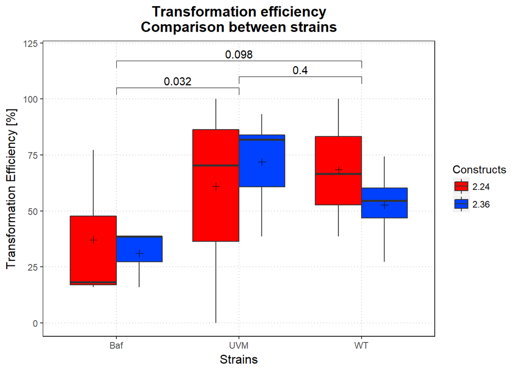

```r
UVM.Tfreq3N$Ab.Name <- factor(UVM.Tfreq3N$Ab.Name, c("2.2","2.18","2.19","2.22","2.23","2.24","2.32","2.35","2.36","2.52","2.53","2.54","pOptV"))
# View(WT.Tfreq3N)

Baf.Tfreq3N$Ab.Name <- factor(Baf.Tfreq3N$Ab.Name, c("2.24","2.35","2.36"))
WT.Tfreq3N$Ab.Name <- factor(WT.Tfreq3N$Ab.Name, c("2.24", "2.32","2.35","2.36"))

# View(UVMBafWT.P2best)
mycompar <- list(c("Baf","UVM"),c("UVM","WT"),c("Baf","WT"))
box.Pbest <- ggplot(UVMBafWT.P2best, aes(x=Strain, y=Trans.eff))
box.Pbest + geom_boxplot(aes(fill =Ab.Name))+
  ylim(0,120)+
  labs(title = "Transformation efficiency\nComparison between strains", x = "Strains", y = "Transformation Efficiency [%]", fill = "Constructs")+
  theme(
    plot.title = element_text(color="black", size=14, face="bold", hjust = 0.5),
    axis.title.x = element_text(color="black", size=12),
    axis.title.y = element_text(color="black", size=12),
    panel.grid.major = element_line(color = "lightgrey",size = 0.5, linetype = 3),
    panel.background = element_rect(fill = "white"),
    panel.border = element_rect(color = "black", fill = NA)
    )+
  scale_fill_manual(values= mycolors)+
  stat_summary(fun.y = mean, geom = "point",shape=3,size=2, aes(x=Strain, group=Ab.Name), position = position_dodge(width = 0.75))+
  stat_compare_means(comparisons = mycompar,label="p.format", label.y = c(105,110,117)) #Welshe's t-test
```

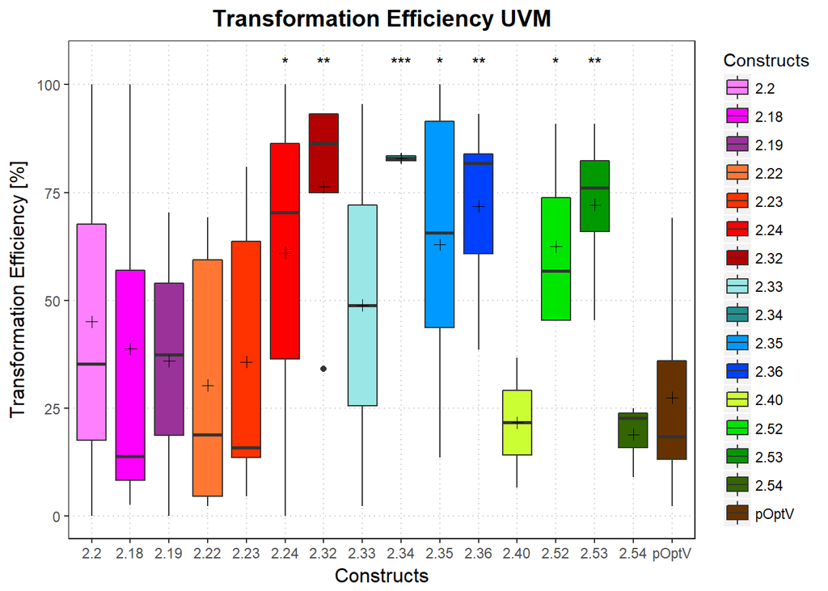

```r
#Plot efficiencies for transformation N=2

View(UVM.TfreqI)
UVM.TfreqI2 <- UVM.TfreqI[!is.element(UVM.TfreqI$Ab.Name, c("2.39", "2.49","2.48","Ctr") ),]

box.UVMTfreqI <- ggplot(UVM.TfreqI2, aes(x=Ab.Name, y=Trans.eff))
box.UVMTfreqI + geom_boxplot(aes(fill = Ab.Name))+
  ylim(0,105)+
  labs(title = "Transformation Efficiency UVM", x = "Constructs", y = "Transformation Efficiency [%]", fill = "Constructs")+
  theme(
    plot.title = element_text(color="black", size=14, face="bold", hjust = 0.5),
    axis.title.x = element_text(color="black", size=12),
    axis.title.y = element_text(color="black", size=12),
    panel.grid.major = element_line(color = "lightgrey",size = 0.5, linetype = 3),
    panel.background = element_rect(fill = "white"),
    panel.border = element_rect(color = "black", fill = NA)
    )+
  scale_fill_manual(values = mycolors)+
  stat_summary(fun.y = mean, geom = "point",shape=3,size=2, position = position_dodge(width = 0.75))+
  stat_compare_means(label="p.signif",label.y = 105, method = "t.test",ref.group = "pOptV", hide.ns = TRUE)
```

```r
Baf.TfreqI
```

```
##    Ab.Name Plate  n  p Trans.eff
## 1      2.2    P1 27 15 55.555556
## 2     2.18    P2 28 11 39.285714
## 3     2.18    P3 13  1  7.692308
## 4     2.19    P2 36 32 88.888889
## 5     2.19    P3 27  6 22.222222
## 6     2.22    P2 44 37 84.090909
## 7     2.22    P3 44 33 75.000000
## 8     2.23    P2 44 26 59.090909
## 9     2.23    P3 44 25 56.818182
## 10    2.24    P3 44  7 15.909091
## 11    2.24    P4 44 34 77.272727
## 12    2.24    P5 44  8 18.181818
## 13    2.32    P5 44 10 22.727273
## 14    2.33    P1 44  2  4.545455
```

[output cut: 17 more lines]

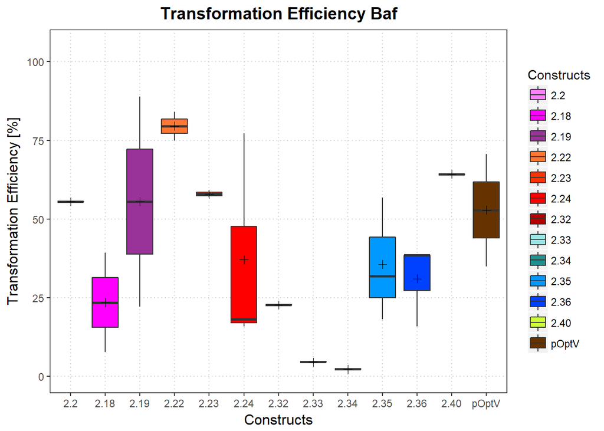

```r
Baf.TfreqI2 <- Baf.TfreqI[!is.element(Baf.TfreqI$Ab.Name, c("2.39", "2.49","2.48","Ctr") ),]

box.BafTfreqI <- ggplot(Baf.TfreqI2, aes(x=Ab.Name, y=Trans.eff))
box.BafTfreqI + geom_boxplot(aes(fill = Ab.Name))+
  ylim(0,105)+
  labs(title = "Transformation Efficiency Baf", x = "Constructs", y = "Transformation Efficiency [%]", fill = "Constructs")+
  theme(
    plot.title = element_text(color="black", size=14, face="bold", hjust = 0.5),
    axis.title.x = element_text(color="black", size=12),
    axis.title.y = element_text(color="black", size=12),
    panel.grid.major = element_line(color = "lightgrey",size = 0.5, linetype = 3),
    panel.background = element_rect(fill = "white"),
    panel.border = element_rect(color = "black", fill = NA)
    )+
  scale_fill_manual(values = mycolors)+
  stat_summary(fun.y = mean, geom = "point",shape=3,size=2, position = position_dodge(width = 0.75))+
  stat_compare_means(label="p.signif",label.y = 105, method = "t.test",ref.group = "pOptV", hide.ns = TRUE)
```

```r
WT.TfreqI
```

```
##    Ab.Name Plate  n  p  Trans.eff
## 1     2.18    P1 42 41  97.619048
## 2     2.19    P1 43 37  86.046512
## 3     2.22    P1 43 29  67.441860
## 4     2.24    P1 44 17  38.636364
## 5     2.24    P2 37 37 100.000000
## 6     2.24    P3 42 28  66.666667
## 7     2.30    P1 44  3   6.818182
## 8     2.31    P1 43 12  27.906977
## 9     2.32    P1 44  9  20.454545
## 10    2.32    P3 44 19  43.181818
## 11    2.32    P4 43 20  46.511628
## 12    2.33    P1 43  2   4.651163
## 13    2.33    P2 44 12  27.272727
## 14    2.34    P1 44  9  20.454545
## 15    2.34    P2 44 22  50.000000
## 16    2.35    P1 44 12  27.272727
## 17    2.35    P2 38 21  55.263158
## 18    2.35    P3 43 41  95.348837
## 19    2.35    P4 43 18  41.860465
## 20    2.36    P1 44 12  27.272727
## 21    2.36    P2 36 20  55.555556
## 22    2.36    P3 43 32  74.418605
## 23    2.36    P4 43 23  53.488372
## 24    2.39    P1 30 12  40.000000
## 25   pOptV    P1 32 29  90.625000
## 26     Ctr    P1 50  2   4.000000
## 27     Ctr    P2 20  4  20.000000
## 28     Ctr    P3 16  5  31.250000
## 29     Ctr    P4 12  0   0.000000
```

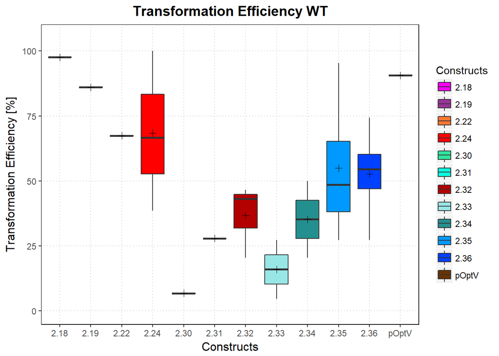

```r
WT.TfreqI2 <- WT.TfreqI[!is.element(WT.TfreqI$Ab.Name, c("2.39", "2.49","2.48","Ctr") ),]

box.WTTfreqI <- ggplot(WT.TfreqI2, aes(x=Ab.Name, y=Trans.eff))
box.WTTfreqI + geom_boxplot(aes(fill = Ab.Name))+
  ylim(0,105)+
  labs(title = "Transformation Efficiency WT", x = "Constructs", y = "Transformation Efficiency [%]", fill = "Constructs")+
  theme(
    plot.title = element_text(color="black", size=14, face="bold", hjust = 0.5),
    axis.title.x = element_text(color="black", size=12),
    axis.title.y = element_text(color="black", size=12),
    panel.grid.major = element_line(color = "lightgrey",size = 0.5, linetype = 3),
    panel.background = element_rect(fill = "white"),
    panel.border = element_rect(color = "black", fill = NA)
    )+
  scale_fill_manual(values = mycolors)+
  stat_summary(fun.y = mean, geom = "point",shape=3,size=2, position = position_dodge(width = 0.75))+
  stat_compare_means(label="p.signif",label.y = 105, method = "t.test",ref.group = "pOptV", hide.ns = TRUE)
```

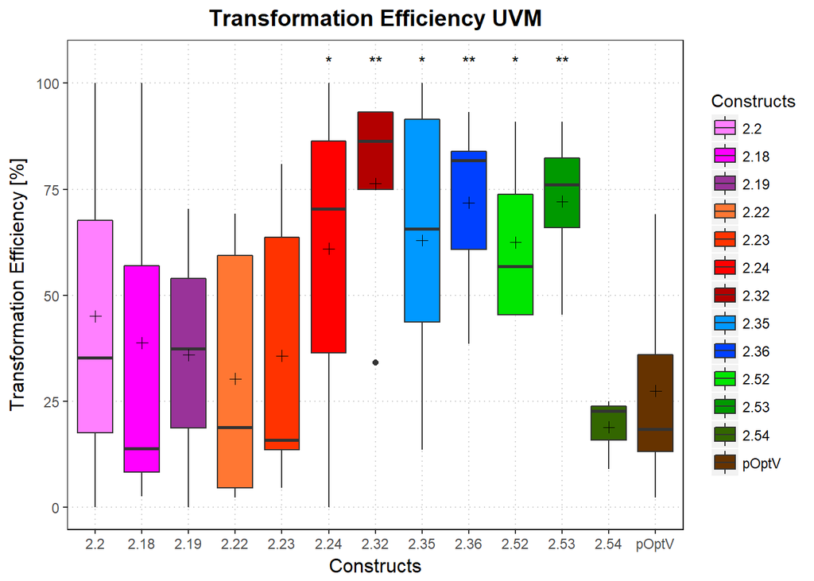

```r
# leveneTest(Trans.eff~Strain*Ab.Name, data = UVMBafWT.P2best)
allTransEff.ANOVA <- aov(Trans.eff~Strain*Ab.Name, data = UVMBafWT.P2best)
# Anova(allTransEff.ANOVA, type = "III")

allbest.2.36 <- UVMBafWT.P2best[which(UVMBafWT.P2best$Ab.Name == "2.36"),]
allbest.ANOVA <- aov(Trans.eff~Strain, data = allbest.2.36)
# Anova(allbest.ANOVA, type = "III")
# TukeyHSD(allbest.ANOVA, which= "Strain")
#
# str(UVMBafWT.P2best)
# pairwise.t.test(UVMBafWT.P2best$Trans.eff, c(UVMBafWT.P2best$Ab.Name))
# pairwise.wilcox.test(UVMBafWT.P2best$Trans.eff,UVMBafWT.P2best$Ab.Name,p.adjust.method = "BH")

poptest <- table(UVMBafWT.P2best$Ab.Name,UVMBafWT.P2best$Strain)
# View(poptest)

# bar.allbest <- ggplot(UVMBafWT.2best, aes(x=Strain, y=Trans.eff.mean, fill = Ab.Name))
# bar.allbest + geom_bar(stat = "identity", position = position_dodge(), color = "black")+
#   theme(
#     plot.title = element_text(color="black", size=14, face="bold", hjust = 0.5),
#     axis.title.x = element_text(color="black", size=12),
#     axis.title.y = element_text(color="black", size=12),
#     panel.grid.major = element_line(color = "lightgrey",size = 0.5, linetype = 3),
#     panel.background = element_rect(fill = "white"),
#     panel.border = element_rect(color = "black", fill = NA)
#     )+
#   ylim(0,100)+
#   scale_fill_manual(values=c("#E69F00", "#56B4E9"))+
#   geom_errorbar(aes(ymin=Trans.eff.mean-Trans.eff.sd, ymax=Trans.eff.mean+Trans.eff.sd), width=.2, position=position_dodge(.9))
#
# View(UVMBafWT.2best)

StrainWilcox <- compare_means(Trans.eff ~ Strain, UVMBafWT.P2best)
ConstrWilcox <- compare_means(Trans.eff ~ Ab.Name, UVMBafWT.P2best, group.by = "Strain")
# ConstrWilcox

box.all3.UVM <- ggplot(UVM.Tfreq3N, aes(x=Ab.Name, y=Trans.eff))

# boxSVG.UVM <- paste("Transformation Efficiency", pName)
# savepath.boxSVG = file.path("C:/Users/KozakPC/Documents","R/Cyto","Results",cleanNo.name)
# svg(filename = paste(savepath.cleanNo, ".svg"), width = 6, height = 5)

box.all3.UVM + geom_boxplot(aes(fill = Ab.Name))+
  ylim(0,105)+
  labs(title = "Transformation Efficiency UVM", x = "Constructs", y = "Transformation Efficiency [%]", fill = "Constructs")+
  theme(
    plot.title = element_text(color="black", size=14, face="bold", hjust = 0.5),
    axis.title.x = element_text(color="black", size=12),
    axis.title.y = element_text(color="black", size=12),
    panel.grid.major = element_line(color = "lightgrey",size = 0.5, linetype = 3),
    panel.background = element_rect(fill = "white"),
    panel.border = element_rect(color = "black", fill = NA)
    )+
  scale_fill_manual(values = mycolors)+
  stat_summary(fun.y = mean, geom = "point",shape=3,size=2, position = position_dodge(width = 0.75))+
  stat_compare_means(label="p.signif",label.y = 105, method = "t.test",ref.group = "pOptV", hide.ns = TRUE)
```

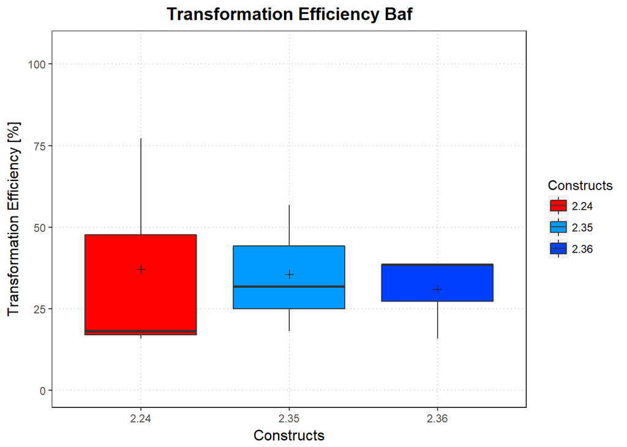

```r
# leveneTest(Trans.eff~Ab.Name, data = UVM.Tfreq3N)
Tfreq.ANOVA <- aov(Trans.eff~Ab.Name, data = UVM.Tfreq3N)
# summary(Tfreq.ANOVA)
# Anova(Tfreq.ANOVA, type = "III")
Tfreq.Tukey <- TukeyHSD(Tfreq.ANOVA, which = "Ab.Name", ordered = T)
# Tfreq.Tukey

UVM.HighTeff <- UVM.Tfreq3N[is.element(UVM.Tfreq3N$Ab.Name,c("2.24","2.32","2.35","2.36", "2.52","2.53")),]
HTeff <- aov(Trans.eff~Ab.Name, data = UVM.HighTeff)
# summary(HTeff)
# TukeyHSD(HTeff, "Ab.Name")

# attach(UVM.posIRES)
# ConTest.UVM.posIRES <- conover.test(Median, g=Ab.Name, method="none", altp = FALSE, wrap = TRUE)
# detach(UVM.posIRES)
# ConTest.UVM.posIRES <- as.data.frame(ConTest.UVM.posIRES)
# ConTest.UVM.posIRES

box.all3.Baf <- ggplot(Baf.Tfreq3N, aes(x=Ab.Name, y=Trans.eff))

box.all3.Baf + geom_boxplot(aes(fill = Ab.Name))+
  ylim(0,105)+
  labs(title = "Transformation Efficiency Baf", x = "Constructs", y = "Transformation Efficiency [%]", fill = "Constructs")+
  theme(
    plot.title = element_text(color="black", size=14, face="bold", hjust = 0.5),
    axis.title.x = element_text(color="black", size=12),
    axis.title.y = element_text(color="black", size=12),
    panel.grid.major = element_line(color = "lightgrey",size = 0.5, linetype = 3),
    panel.background = element_rect(fill = "white"),
    panel.border = element_rect(color = "black", fill = NA)
    )+
  scale_fill_manual(values = mycolors)+
  stat_summary(fun.y = mean, geom = "point",shape=3,size=2, position = position_dodge(width = 0.75))+
  stat_compare_means(label="p.signif",label.y = 105, method = "t.test", hide.ns = TRUE)
```

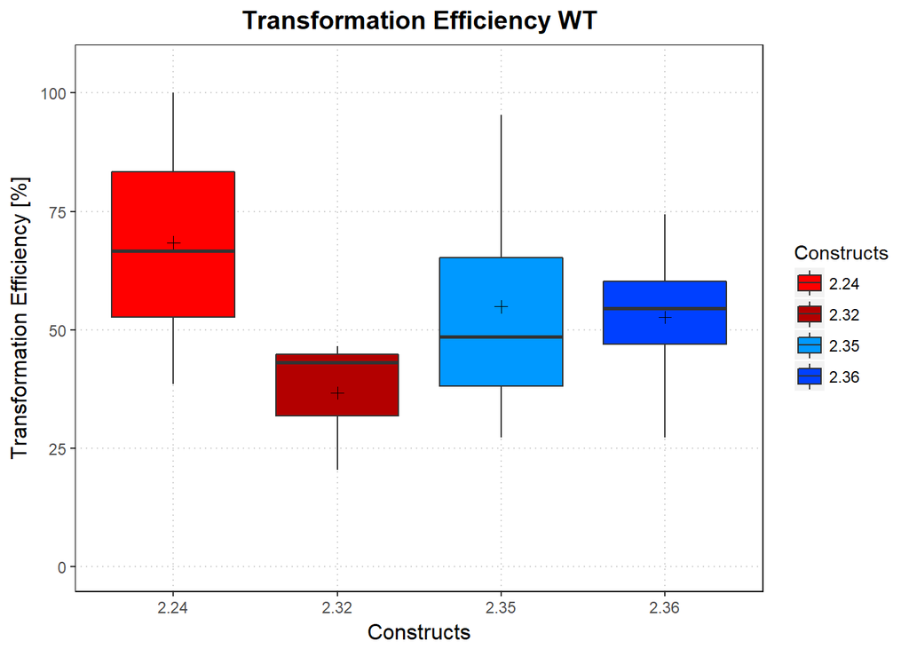

```r
box.all3.WT <- ggplot(WT.Tfreq3N, aes(x=Ab.Name, y=Trans.eff))

box.all3.WT + geom_boxplot(aes(fill = Ab.Name))+
  ylim(0,105)+
  labs(title = "Transformation Efficiency WT", x = "Constructs", y = "Transformation Efficiency [%]", fill = "Constructs")+
  theme(
    plot.title = element_text(color="black", size=14, face="bold", hjust = 0.5),
    axis.title.x = element_text(color="black", size=12),
    axis.title.y = element_text(color="black", size=12),
    panel.grid.major = element_line(color = "lightgrey",size = 0.5, linetype = 3),
    panel.background = element_rect(fill = "white"),
    panel.border = element_rect(color = "black", fill = NA)
    )+
  scale_fill_manual(values = mycolors)+
  stat_summary(fun.y = mean, geom = "point",shape=3,size=2, position = position_dodge(width = 0.75))+
  stat_compare_means(label="p.signif",label.y = 105, method = "t.test", hide.ns = TRUE)
```

```r
mycompar2 <- list(c("2.24","2.32"),c("2.24","2.35"),c("2.24","2.36"),c("2.32","2.36"))


compare.list <- list(c("2.24","2.32"),c("2.35","2.36"))

UVM3N.Wilcox <- compare_means(Trans.eff ~ Ab.Name, UVM.Tfreq3N)
UVM3N.ttest <- compare_means(Trans.eff ~ Ab.Name, UVM.Tfreq3N, ref.group = "pOptV", method = "t.test")
# UVM3N.ttest
# View(UVM3N.Wilcox)
```

##**Plotting and other representations** Use point plots for showing percent data and threshold applied Use boxplots for subets comparisons #### Boxplots all samples with % thresholds

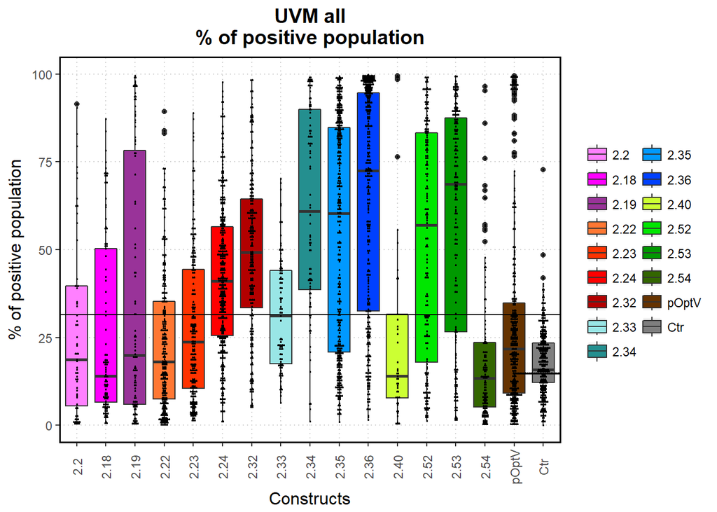

```r
UVM.Tfreq3N$Ab.Name <- factor(UVM.Tfreq3N$Ab.Name, c("2.2","2.18","2.19","2.22","2.23","2.24","2.32","2.35","2.36","2.52","2.53","2.54","pOptV"))

UVMFD.short <- UVM.FD[is.element(UVM.FD$Ab.Name,c("2.2","2.18","2.19","2.22","2.23","2.24","2.32", "2.33", "2.34","2.35","2.36", "2.40","2.52","2.53","2.54","pOptV", "Ctr")),]
# str(UVMFD.short)
box.UVM.FD <- ggplot(UVMFD.short, aes(x=Ab.Name, y=PercentPositives))

box.UVM.FD + geom_boxplot(aes(fill= Ab.Name))+
  labs(title = "UVM all\n% of positive population", x = "Constructs", y = "% of positive population")+
  theme(
        axis.text.x = element_text(angle = 90, vjust = 0.5),
        plot.title = element_text(color="black", size=14, face="bold", hjust = 0.5),
        axis.title.x = element_text(color="black", size=12),
        axis.title.y = element_text(color="black", size=12),
        line = element_line(colour = "black", size = 0.5, linetype = 1, lineend = "butt"),
        rect = element_rect(fill = "white", colour = "black", size = 2.5, linetype = 1),
        panel.border = element_rect(size = 1, fill = NA),
        panel.background = element_rect(fill = "white"),
        panel.grid.major = element_line(color = "lightgrey",size = 0.5, linetype = 3),
        legend.title = element_blank()
    )+
  ylim(0,100)+
  scale_fill_manual(values = mycolors)+
  geom_dotplot(stackdir = "center", binaxis = "y", binwidth = 0.4)+
  geom_hline(yintercept=UVM.Per.threshold)+
  guides(fill=guide_legend(ncol=2))
```

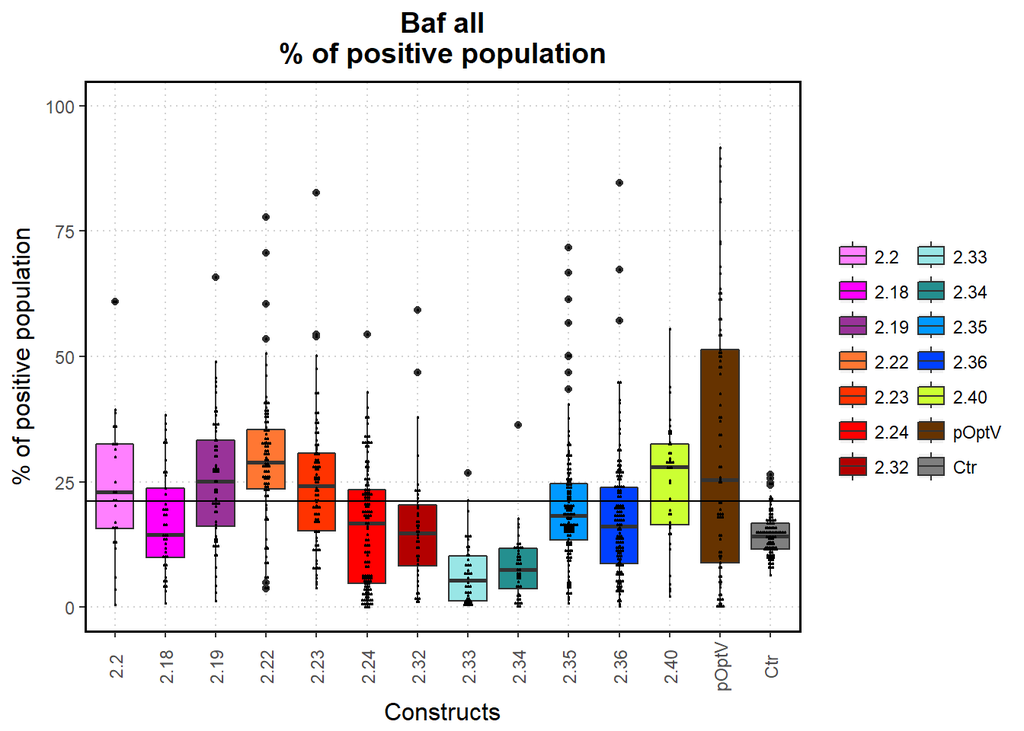

```r
box.Baf.FD <- ggplot(Baf.FD, aes(x=Ab.Name, y=PercentPositives))

box.Baf.FD + geom_boxplot(aes(fill= Ab.Name))+
  labs(title = "Baf all\n% of positive population", x = "Constructs", y = "% of positive population")+
  theme(
        axis.text.x = element_text(angle = 90, vjust = 0.5),
        plot.title = element_text(color="black", size=14, face="bold", hjust = 0.5),
        axis.title.x = element_text(color="black", size=12),
        axis.title.y = element_text(color="black", size=12),
        line = element_line(colour = "black", size = 0.5, linetype = 1, lineend = "butt"),
        rect = element_rect(fill = "white", colour = "black", size = 2.5, linetype = 1),
        panel.border = element_rect(size = 1, fill = NA),
        panel.background = element_rect(fill = "white"),
        panel.grid.major = element_line(color = "lightgrey",size = 0.5, linetype = 3),
        legend.title = element_blank()
    )+
  ylim(0,100)+
  scale_fill_manual(values = mycolors)+
  geom_dotplot(stackdir = "center", binaxis = "y", binwidth = 0.4)+
  geom_hline(yintercept=Baf.Per.threshold)+
  guides(fill=guide_legend(ncol=2))
```

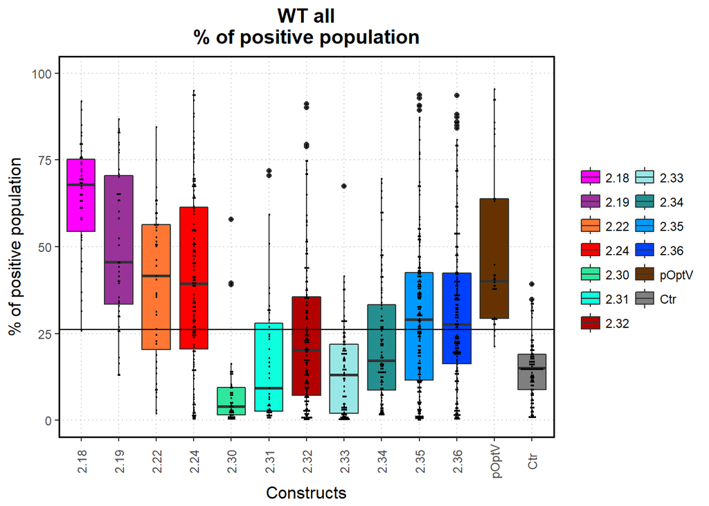

```r
WTFD.short <- WT.FD[is.element(WT.FD$Ab.Name,c("2.18","2.19","2.22","2.24", "2.30", "2.31","2.32", "2.33", "2.34","2.35","2.36","pOptV", "Ctr")),]

box.WT.FD <- ggplot(WTFD.short, aes(x=Ab.Name, y=PercentPositives))

box.WT.FD + geom_boxplot(aes(fill= Ab.Name))+
  labs(title = "WT all\n% of positive population", x = "Constructs", y = "% of positive population")+
  theme(
        axis.text.x = element_text(angle = 90, vjust = 0.5),
        plot.title = element_text(color="black", size=14, face="bold", hjust = 0.5),
        axis.title.x = element_text(color="black", size=12),
        axis.title.y = element_text(color="black", size=12),
        line = element_line(colour = "black", size = 0.5, linetype = 1, lineend = "butt"),
        rect = element_rect(fill = "white", colour = "black", size = 2.5, linetype = 1),
        panel.border = element_rect(size = 1, fill = NA),
        panel.background = element_rect(fill = "white"),
        panel.grid.major = element_line(color = "lightgrey",size = 0.5, linetype = 3),
        legend.title = element_blank()
    )+
  ylim(0,100)+
  scale_fill_manual(values = mycolors)+
  geom_dotplot(stackdir = "center", binaxis = "y", binwidth = 0.4)+
  geom_hline(yintercept=WT.Per.threshold)+
  guides(fill=guide_legend(ncol=2))
```

#### Point plots

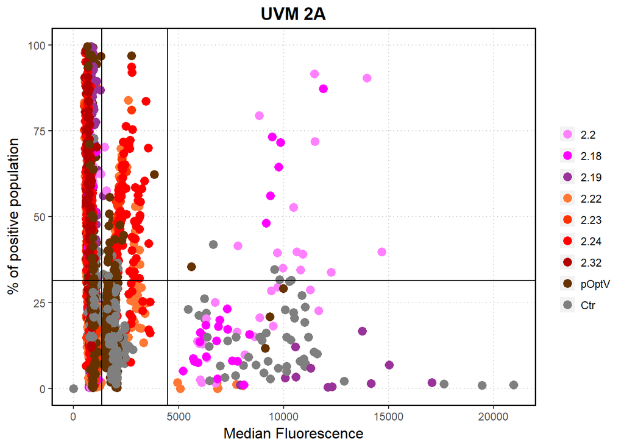

```r
pnt.UVM.2A <- ggplot(UVM.2A, aes(x=Median, y=PercentPositives, color = Ab.Name))

pnt.UVM.2A + geom_point(size=3, aes(fill=Ab.Name))+
  labs(title = "UVM 2A", x = "Median Fluorescence", y = "% of positive population")+
  theme(
        axis.text.x = element_text(angle = 0, vjust = 0.5),
        plot.title = element_text(color="black", size=14, face="bold", hjust = 0.5),
        axis.title.x = element_text(color="black", size=12),
        axis.title.y = element_text(color="black", size=12),
        line = element_line(colour = "black", size = 0.5, linetype = 1, lineend = "butt"),
        rect = element_rect(fill = "white", colour = "black", size = 2.5, linetype = 1),
        panel.border = element_rect(size = 1, fill = NA),
        panel.background = element_rect(fill = "white"),
        panel.grid.major = element_line(color = "lightgrey",size = 0.5, linetype = 3),
        legend.title = element_blank()
    )+
  ylim(0,100)+
  scale_color_manual(values = mycolors)+
  geom_vline(xintercept = 1.5*UVM.median.V)+
  geom_vline(xintercept = 5*UVM.median.V)+
  geom_hline(yintercept=UVM.Per.threshold)
```

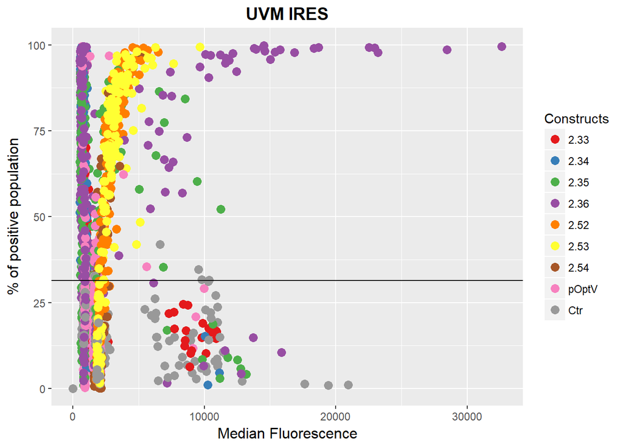

```r
pnt.UVM.IRES <- ggplot(UVM.IRES, aes(x=Median, y=PercentPositives, color = Ab.Name))

pnt.UVM.IRES + geom_point(size=3)+
  labs(title = "UVM IRES", x = "Median Fluorescence", y = "% of positive population")+
  theme(
    plot.title = element_text(color="black", size=14, face="bold", hjust = 0.5),
    axis.title.x = element_text(color="black", size=12),
    axis.title.y = element_text(color="black", size=12))+
  ylim(0,100)+
  scale_color_brewer(type="div", palette = "Set1", name = "Constructs")+
  geom_hline(yintercept=UVM.Per.threshold)
```

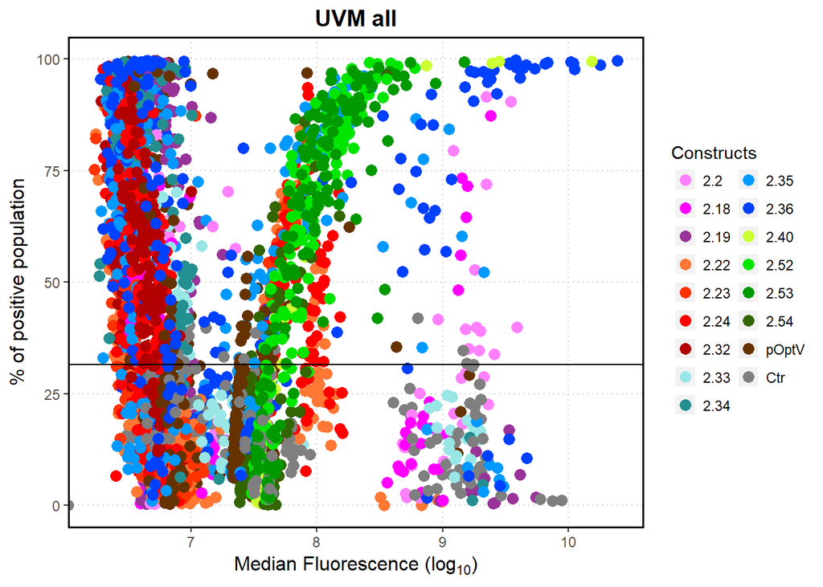

```r
UVM.FD$MedianLog <- log(UVM.FD$Median)
# View(UVM.FD)

UVM.pntFoc <- UVM.FD[!is.element(UVM.FD$Ab.Name, c("2.39","2.48","2.49")),]

pnt.UVM.pntLog <- ggplot(UVM.pntFoc, aes(x=MedianLog, y=PercentPositives, color = Ab.Name))

pnt.UVM.pntLog + geom_point(size=3)+
  labs(title = "UVM all", x = expression("Median Fluorescence (log"[10]*")"), y = "% of positive population")+
  theme(
        axis.text.x = element_text(angle = 0, vjust = 0.5),
        plot.title = element_text(color="black", size=14, face="bold", hjust = 0.5),
        axis.title.x = element_text(color="black", size=12),
        axis.title.y = element_text(color="black", size=12),
        line = element_line(colour = "black", size = 0.5, linetype = 1, lineend = "butt"),
        rect = element_rect(fill = "white", colour = "black", size = 2.5, linetype = 1),
        panel.border = element_rect(size = 1, fill = NA),
        panel.background = element_rect(fill = "white"),
        panel.grid.major = element_line(color = "lightgrey",size = 0.5, linetype = 3)
    )+
  ylim(0,100)+
  scale_color_manual(values = mycolors, name = "Constructs")+
  geom_hline(yintercept=UVM.Per.threshold)+
  guides(color=guide_legend(ncol=2))
```

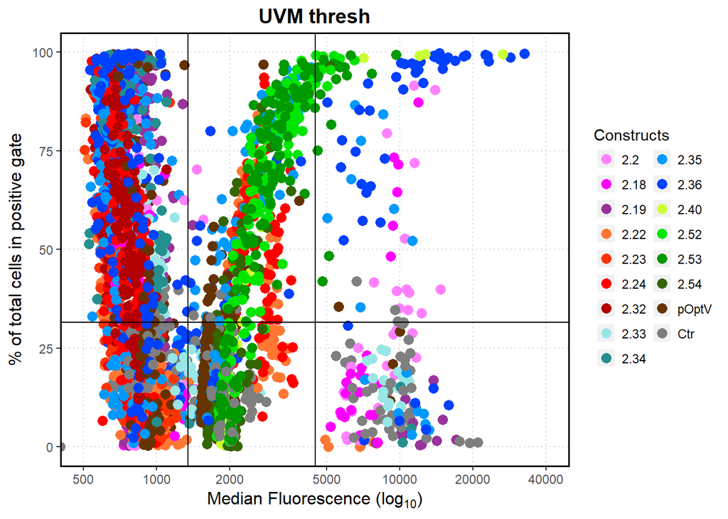

```r
pnt.UVM.pnt <- ggplot(UVM.pntFoc, aes(x=Median, y=PercentPositives, color = Ab.Name))

pnt.UVM.pnt + geom_point(size=3)+
  labs(title = "UVM thresh", x = expression("Median Fluorescence (log"[10]*")"), y = "% of total cells in positive gate")+
  theme(
        axis.text.x = element_text(angle = 0, vjust = 0.5),
        plot.title = element_text(color="black", size=14, face="bold", hjust = 0.5),
        axis.title.x = element_text(color="black", size=12),
        axis.title.y = element_text(color="black", size=12),
        line = element_line(colour = "black", size = 0.5, linetype = 1, lineend = "butt"),
        rect = element_rect(fill = "white", colour = "black", size = 2.5, linetype = 1),
        panel.border = element_rect(size = 1, fill = NA),
        panel.background = element_rect(fill = "white"),
        panel.grid.major = element_line(color = "lightgrey",size = 0.5, linetype = 3)
    )+
  ylim(0,100)+
  scale_x_log10(breaks=c(100,500,1000,2000,5000,10000,20000,40000), limits = c(500,40000))+
  scale_color_manual(values = mycolors, name = "Constructs")+
  geom_vline(xintercept = 1.5*UVM.median.V)+
  geom_vline(xintercept = 5*UVM.median.V)+
  geom_hline(yintercept=UVM.Per.threshold)+
  guides(color=guide_legend(ncol=2))
```

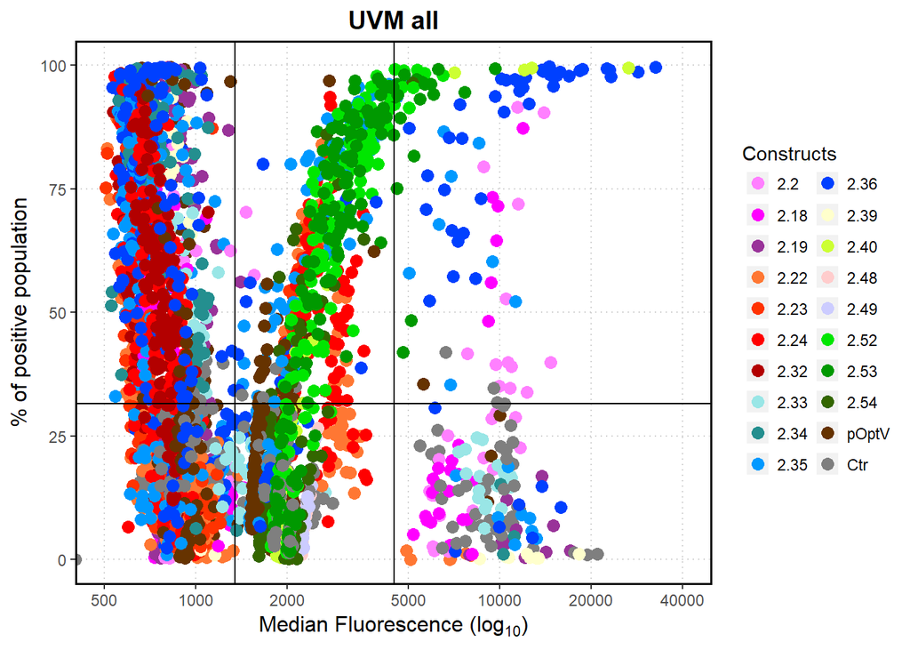

```r
pnt.UVM.FD <- ggplot(UVM.FD, aes(x=Median, y=PercentPositives, color = Ab.Name))

pnt.UVM.FD + geom_point(size=3)+
  labs(title = "UVM all", x = expression("Median Fluorescence (log"[10]*")"), y = "% of positive population")+
  theme(
        axis.text.x = element_text(angle = 0, vjust = 0.5),
        plot.title = element_text(color="black", size=14, face="bold", hjust = 0.5),
        axis.title.x = element_text(color="black", size=12),
        axis.title.y = element_text(color="black", size=12),
        line = element_line(colour = "black", size = 0.5, linetype = 1, lineend = "butt"),
        rect = element_rect(fill = "white", colour = "black", size = 2.5, linetype = 1),
        panel.border = element_rect(size = 1, fill = NA),
        panel.background = element_rect(fill = "white"),
        panel.grid.major = element_line(color = "lightgrey",size = 0.5, linetype = 3)
    )+
  ylim(0,100)+
  scale_x_log10(breaks=c(100,500,1000,2000,5000,10000,20000,40000), limits = c(500,40000))+
  scale_color_manual(values = mycolors, name = "Constructs")+
  geom_vline(xintercept = 1.5*UVM.median.V)+
  geom_vline(xintercept = 5*UVM.median.V)+
  geom_hline(yintercept=UVM.Per.threshold)+
  guides(color=guide_legend(ncol=2))
```

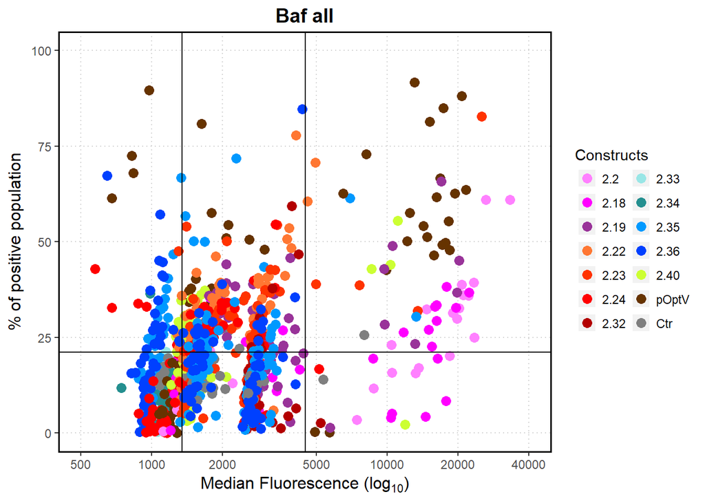

```r
pnt.Baf.FD <- ggplot(Baf.FD, aes(x=Median, y=PercentPositives, color = Ab.Name))

pnt.Baf.FD + geom_point(size=3)+
  labs(title = "Baf all", x = expression("Median Fluorescence (log"[10]*")"), y = "% of positive population")+
  theme(
        axis.text.x = element_text(angle = 0, vjust = 0.5),
        plot.title = element_text(color="black", size=14, face="bold", hjust = 0.5),
        axis.title.x = element_text(color="black", size=12),
        axis.title.y = element_text(color="black", size=12),
        line = element_line(colour = "black", size = 0.5, linetype = 1, lineend = "butt"),
        rect = element_rect(fill = "white", colour = "black", size = 2.5, linetype = 1),
        panel.border = element_rect(size = 1, fill = NA),
        panel.background = element_rect(fill = "white"),
        panel.grid.major = element_line(color = "lightgrey",size = 0.5, linetype = 3)
    )+
  ylim(0,100)+
  scale_x_log10(breaks=c(100,500,1000,2000,5000,10000,20000,40000), limits = c(500,40000))+
  scale_color_manual(values = mycolors, name = "Constructs")+
  geom_vline(xintercept = 1.5*UVM.median.V)+
  geom_vline(xintercept = 5*UVM.median.V)+
  geom_hline(yintercept=Baf.Per.threshold)+
  guides(color=guide_legend(ncol=2))
```

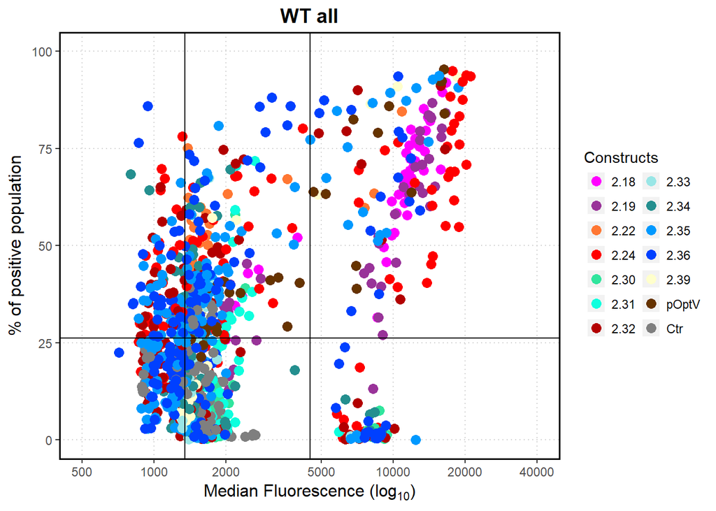

```r
pnt.WT.FD <- ggplot(WT.FD, aes(x=Median, y=PercentPositives, color = Ab.Name))

pnt.WT.FD + geom_point(size=3)+
  labs(title = "WT all", x = expression("Median Fluorescence (log"[10]*")"), y = "% of positive population")+
  theme(
        axis.text.x = element_text(angle = 0, vjust = 0.5),
        plot.title = element_text(color="black", size=14, face="bold", hjust = 0.5),
        axis.title.x = element_text(color="black", size=12),
        axis.title.y = element_text(color="black", size=12),
        line = element_line(colour = "black", size = 0.5, linetype = 1, lineend = "butt"),
        rect = element_rect(fill = "white", colour = "black", size = 2.5, linetype = 1),
        panel.border = element_rect(size = 1, fill = NA),
        panel.background = element_rect(fill = "white"),
        panel.grid.major = element_line(color = "lightgrey",size = 0.5, linetype = 3)
    )+
  ylim(0,100)+
  scale_x_log10(breaks=c(100,500,1000,2000,5000,10000,20000,40000), limits = c(500,40000))+
  scale_color_manual(values = mycolors, name = "Constructs")+
  geom_vline(xintercept = 1.5*UVM.median.V)+
  geom_vline(xintercept = 5*UVM.median.V)+
  geom_hline(yintercept=WT.Per.threshold)+
  guides(color=guide_legend(ncol=2))
```

####Boxplots of fluorescence and H/M/L thresholds

```r
library(conover.test)
# leveneTest(Median~Ab.Name, data = UVM.pos2A)
model2A.gls <- gls(Median ~ Ab.Name, data = UVM.pos2A, weights = varIdent(form = ~1 | Ab.Name))
mod2.2A.AOV <- anova(model2A.gls)
# kruskal.test(Median~Ab.Name, data = UVM.pos2A)

attach(UVM.pos2A)
ConTest.UVM.pos2A <- conover.test(Median, g=Ab.Name, method="none", altp = FALSE, wrap = TRUE)
```

```
##   Kruskal-Wallis rank sum test
##
## data: Median and Ab.Name
## Kruskal-Wallis chi-squared = 131.4101, df = 7, p-value = 0
##
##
##                         Comparison of Median by Ab.Name
##                                 (No adjustment)
## Col Mean-|
## Row Mean |       2.18       2.19        2.2       2.22       2.23       2.24       2.32
## ---------+-----------------------------------------------------------------------------
##     2.19 |  -1.773027
##          |     0.0383
##      2.2 |  -4.770695  -3.460962
##          |    0.0000*    0.0003*
##     2.22 |   0.073347   2.214544   5.440112
##          |     0.4708    0.0135*    0.0000*
##     2.23 |   1.025318   3.275938   6.276012   1.211726
##          |     0.1528    0.0006*    0.0000*     0.1130
##     2.24 |  -0.972996   1.384821   5.055030  -1.465509  -3.004538
##          |     0.1654     0.0833    0.0000*     0.0716    0.0014*
##     2.32 |   3.797621   6.631952   8.877822   5.048532   3.704166   8.962189
##          |    0.0001*    0.0000*    0.0000*    0.0000*    0.0001*    0.0000*
##    pOptV |  -1.871027   0.195918   3.993690  -2.544537  -3.895136  -1.637565  -8.745770
##          |     0.0309     0.4224    0.0000*    0.0056*    0.0001*     0.0510    0.0000*
##
## alpha = 0.05
## Reject Ho if p <= alpha/2
```

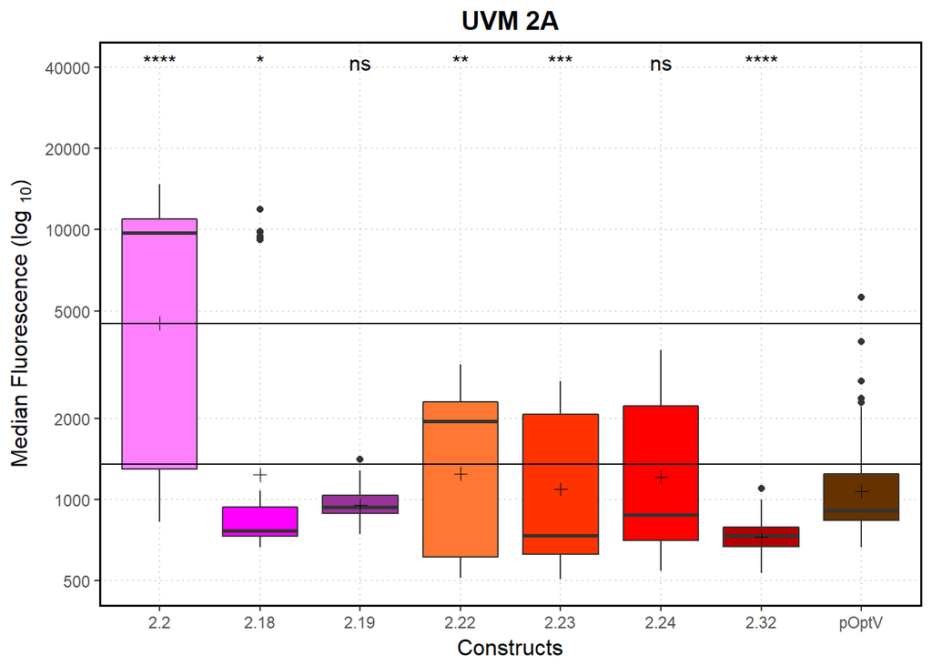

```r
detach(UVM.pos2A)
ConTest.UVM.pos2A <- as.data.frame(ConTest.UVM.pos2A)

UVM.2Aex <- UVM.pos2A %>%
  group_by(Ab.Name) %>%
  count()
UVM.2Aex=as.data.frame(UVM.2Aex)
colnames(UVM.2Aex) <- c("Constructs","Total Positives")
# View(UVM.2Aex)

# summary(model2A.gls)
# intervals(model2A.gls)

box.UVM.pos2A <- ggplot(UVM.pos2A, aes(x=Ab.Name, y=Median))
labels.UVM.pos2A <- data.frame(Ab.Name = c("2.2","2.18","2.19","2.22","2.23","2.24","2.32","pOptV"), Median = c(40000))
box.UVM.pos2A + geom_boxplot(aes(fill =Ab.Name))+
  labs(title = "UVM 2A", x = "Constructs", y = expression("Median Fluorescence (log  "[10]*")"), fill = "Constructs")+
  theme(
        axis.text.x = element_text(angle = 0, vjust = 0.5),
        plot.title = element_text(color="black", size=14, face="bold", hjust = 0.5),
        axis.title.x = element_text(color="black", size=12),
        axis.title.y = element_text(color="black", size=12),
        line = element_line(colour = "black", size = 0.5, linetype = 1, lineend = "butt"),
        rect = element_rect(fill = "white", colour = "black", size = 2.5, linetype = 1),
        panel.border = element_rect(size = 1, fill = NA),
        panel.background = element_rect(fill = "white"),
        panel.grid.major = element_line(color = "lightgrey",size = 0.5, linetype = 3),
        legend.position = "none"
    )+
  scale_y_log10(breaks=c(100,500,1000,2000,5000,10000,20000,40000), limits = c(500,40000))+
  geom_hline(yintercept = 1.5*UVM.median.V)+
  geom_hline(yintercept = 5*UVM.median.V)+
  scale_fill_manual(values = mycolors, name = "Constructs")+
  guides(color=guide_legend(ncol=2))+
  stat_summary(fun.y = mean, geom = "point",shape=3,size=2, position = position_dodge(width = 0.75))+
  geom_text(data = labels.UVM.pos2A, label = c("****","*","ns","**","***","ns","****",""), size = 4, vjust = 0.2)
```

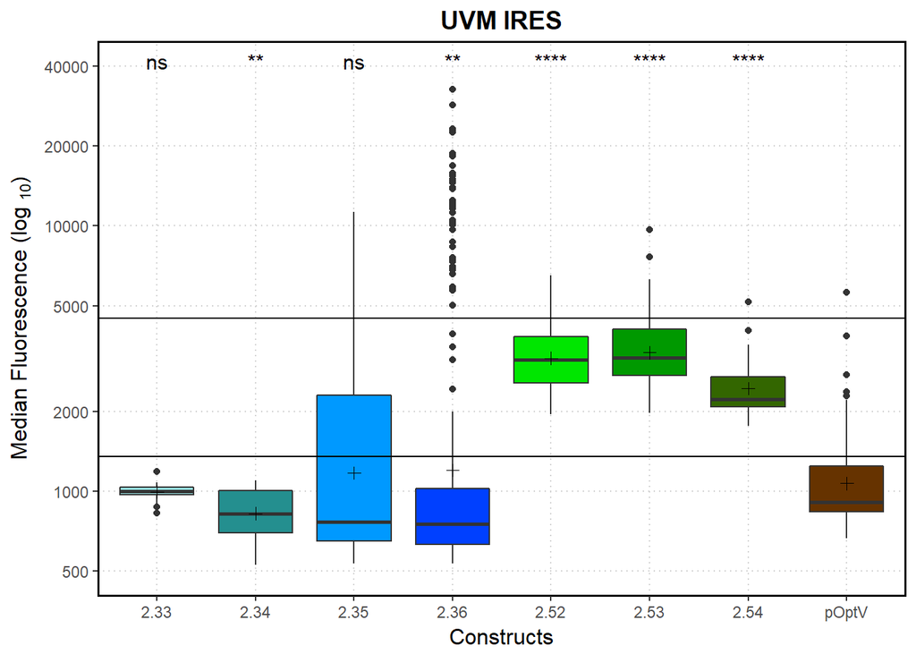

```r
# Signif. codes: '****' 0; '***' 0.001; '**' 0.01; '*' 0.05; 'ns' >0.05;

# stat_compare_means(label="p.signif",ref.group = "pOptV", hide.ns = TRUE) #Welshe's t-test
# leveneTest(Trans.eff~Strain*Ab.Name, data = UVMBafWT.P2best)
# allTransEff.ANOVA <- aov(Trans.eff~Strain*Ab.Name, data = UVMBafWT.P2best)
# Anova(allTransEff.ANOVA, type = "III")
allbest.2.36 <- UVMBafWT.P2best[which(UVMBafWT.P2best$Ab.Name == "2.36"),]
allbest.ANOVA <- aov(Trans.eff~Strain, data = allbest.2.36)
# Anova(allbest.ANOVA, type = "III")
# TukeyHSD(allbest.ANOVA, which= "Strain")
# #
# str(UVMBafWT.P2best)
# pairwise.t.test(UVMBafWT.P2best$Trans.eff, c(UVMBafWT.P2best$Ab.Name))
# pairwise.wilcox.test(UVMBafWT.P2best$Trans.eff,UVMBafWT.P2best$Ab.Name,p.adjust.method = "BH")
#
# poptest <- table(UVMBafWT.P2best$Ab.Name,UVMBafWT.P2best$Strain)
# View(poptest)

box.UVM.posIRES <- ggplot(UVM.posIRES, aes(x=Ab.Name, y=Median))
labels.UVM.posIRES <- data.frame(Ab.Name = c("2.33","2.34","2.35","2.36","2.52","2.53","2.54","pOptV"), Median = c(40000))

box.UVM.posIRES + geom_boxplot(aes(fill =Ab.Name))+
   labs(title = "UVM IRES", x = "Constructs", y = expression("Median Fluorescence (log  "[10]*")"), fill = "Constructs")+
  theme(
        axis.text.x = element_text(angle = 0, vjust = 0.5),
        plot.title = element_text(color="black", size=14, face="bold", hjust = 0.5),
        axis.title.x = element_text(color="black", size=12),
        axis.title.y = element_text(color="black", size=12),
        line = element_line(colour = "black", size = 0.5, linetype = 1, lineend = "butt"),
        rect = element_rect(fill = "white", colour = "black", size = 2.5, linetype = 1),
        panel.border = element_rect(size = 1, fill = NA),
        panel.background = element_rect(fill = "white"),
        panel.grid.major = element_line(color = "lightgrey",size = 0.5, linetype = 3),
        legend.position = "none"
    )+
  scale_y_log10(breaks=c(100,500,1000,2000,5000,10000,20000,40000), limits = c(500,40000))+
  geom_hline(yintercept = 1.5*UVM.median.V)+
  geom_hline(yintercept = 5*UVM.median.V)+
  scale_fill_manual(values = mycolors, name = "Constructs")+
  guides(fill=guide_legend(nrow=1))+
  stat_summary(fun.y = mean, geom = "point",shape=3,size=2, position = position_dodge(width = 0.75))+
  geom_text(data = labels.UVM.posIRES, label = c("ns","**","ns","**","****","****","****",""), size = 4, vjust = 0.2)
```

```r
# Signif. codes: '****' 0; '***' 0.001; '**' 0.01; '*' 0.05; 'ns' >0.05;

attach(UVM.posIRES)
ConTest.UVM.posIRES <- conover.test(Median, g=Ab.Name, method="none", altp = FALSE, wrap = TRUE)
```

```
##   Kruskal-Wallis rank sum test
##
## data: Median and Ab.Name
## Kruskal-Wallis chi-squared = 348.3586, df = 7, p-value = 0
##
##
##                         Comparison of Median by Ab.Name
##                                 (No adjustment)
## Col Mean-|
## Row Mean |       2.33       2.34       2.35       2.36       2.52       2.53       2.54
## ---------+-----------------------------------------------------------------------------
##     2.34 |   3.344985
##          |    0.0004*
##     2.35 |   2.288451  -1.942054
##          |    0.0112*     0.0262
##     2.36 |   3.087721  -0.983676   1.399840
##          |    0.0010*     0.1628     0.0809
##     2.52 |  -7.086241  -12.70186  -14.20981  -15.50076
##          |    0.0000*    0.0000*    0.0000*    0.0000*
##     2.53 |  -7.587111  -13.49208  -15.47022  -16.84849  -0.492661
##          |    0.0000*    0.0000*    0.0000*    0.0000*     0.3112
##     2.54 |  -3.347597  -6.408196  -5.799046  -6.438746   1.952160   2.270090
##          |    0.0004*    0.0000*    0.0000*    0.0000*     0.0256    0.0117*
##    pOptV |   1.021553  -2.982819  -1.634754  -2.754174   10.62296   11.46513   4.604992
##          |     0.1536    0.0015*     0.0512    0.0030*    0.0000*    0.0000*    0.0000*
##
## alpha = 0.05
## Reject Ho if p <= alpha/2
```

```r
detach(UVM.posIRES)
ConTest.UVM.posIRES <- as.data.frame(ConTest.UVM.posIRES)
write.csv(ConTest.UVM.posIRES,"ConoverT_UVMposIRES.csv")

geom_signif(stat = "identity",
              data=data.frame(x=c(1,2,3,4,5,6,7,8),y=c(39900), annotation=c("ns","ns","*","**","*","*","**","")),
              aes(x=x,xend=x,y=y,yend=y, annotation=annotation))
```

```
## mapping: x = x, y = y, xend = x, yend = y, annotation = annotation
## geom_signif: na.rm = FALSE
## stat_identity: na.rm = FALSE
## position_identity
```

```r
label = c("ns","ns","p=0.012","p=0.004","p=0.015","p=0.013","p=0.008","")
labels.UVM.posIRES <- data.frame(Ab.Name = c("2.33","2.34","2.35","2.36","2.52","2.53","2.54","pOptV"), Median = c(40000))
# labels.UVM.posIRES
```

####Statistic on heteroscedastic data using Generalized Least Square model fit using REsidual Maximum Likelihood (GLS fit w/ REML)

```r
#use generalised least square model for modeling variances and running anova

# leveneTest(Median~Ab.Name, data = UVM.posIRES)
model1.gls <- gls(Median ~ Ab.Name, data = UVM.posIRES, weights = varIdent(form = ~1 | Ab.Name))
# anova(model1.gls)
# summary(model1.gls)
# intervals(model1.gls)

#Box_Cox transformation
BCtran.Mod = BoxCoxTrans(UVM.posIRES$Median)
UVM.posIRES = cbind(UVM.posIRES, BC_Median=predict(BCtran.Mod, UVM.posIRES$Median))
lmMod.BC <- lm(BC_Median ~ Ab.Name, data = UVM.posIRES)
# bptest(lmMod.BC) # but still p<<0.05, log transformation also doesn't help


allTransEff.ANOVA <- aov(Trans.eff~Strain*Ab.Name, data = UVMBafWT.P2best)
# Anova(allTransEff.ANOVA, type = "III")
allbest.2.36 <- UVMBafWT.P2best[which(UVMBafWT.P2best$Ab.Name == "2.36"),]
allbest.ANOVA <- aov(Trans.eff~Strain, data = allbest.2.36)
# Anova(allbest.ANOVA, type = "III")
# TukeyHSD(allbest.ANOVA, which= "Strain")
```

####Apply expression threshold accross whole data and create new categorical variable

```r
# UVMposF.ANOVA <- aov(Median~Plate+Ab.Name, data = UVM.posF)
# # Anova(UVMposF.ANOVA, type = "III")
# # TukeyHSD(UVMposF.ANOVA, which = "Plate")
# myvars <- c("Ab.Name","Plate","Median")
# UVMposF.3var <- UVM.posF[myvars]
# # plot(UVMposF.3var)
# # View(UVM.posF)
# mlr.UVMpos <- lm(Median~Ab.Name+Plate, data = UVMposF.3var)
# # summary(mlr.UVMpos)
# per.mlr.UVMposF <- lm(PercentPositives~Ab.Name*plateName, data = UVM.posF)
# results.per <- summary(per.mlr.UVMposF)
# # plot(per.mlr.UVMposF)
#
# red.mlr.UVMposF <- lm(Median~Ab.Name*Plate, data = UVM.posF)
# # plot(red.mlr.UVMposF)
# # summary(red.mlr.UVMposF)
write.csv(UVM.posF, "UVMposF.csv")

UVMposF.tab <- xtabs(Median~Ab.Name+Plate, UVM.posF)
# UVMposF.tab
# UVMpos.lglm1 <- loglm(Median~Ab.Name+Plate, data = UVM.posF)
#
# UVMpos.lglm2 <- loglm(~Ab.Name*Plate, data = UVMposF.tab)
# anova(UVMpos.lglm1,UVMpos.lglm2)

ca(UVMposF.tab)
```

```
##
##  Principal inertias (eigenvalues):
##            1        2        3       4        5        6        7
## Value      0.623973 0.401312 0.25811 0.235203 0.144155 0.053899 0.026665
## Percentage 35.61%   22.9%    14.73%  13.42%   8.23%    3.08%    1.52%
##            8
## Value      0.008807
## Percentage 0.5%
##
##
##  Rows:
##               2.2     2.18      2.19      2.22      2.23      2.24
## Mass     0.049225 0.026132  0.013374  0.036659  0.032509  0.112536
## ChiDist  2.187219 2.083550  1.860582  1.368773  2.311916  0.917696
## Inertia  0.235487 0.113442  0.046298  0.068682  0.173760  0.094774
## Dim. 1   1.082158 0.410379  1.600545 -0.995281 -0.101694 -0.777659
## Dim. 2  -1.336203 2.171940 -0.371036  0.029874  2.612844  0.436653
##              2.32     2.33      2.34      2.35      2.36      2.52
## Mass     0.039779 0.013905  0.019896  0.118448  0.217930  0.116760
## ChiDist  0.969897 2.533765  1.703601  1.140087  1.214176  1.071986
## Inertia  0.037420 0.089269  0.057743  0.153959  0.321277  0.134175
## Dim. 1  -0.673516 1.847961  1.493993 -0.782355 -1.027951  1.211674
## Dim. 2   0.272173 0.089618 -0.569422  1.322588 -1.216884 -0.089604
##              2.53     2.54    pOptV
## Mass     0.143387 0.020470 0.038992
## ChiDist  1.036659 1.482171 0.828693
## Inertia  0.154092 0.044968 0.026777
## Dim. 1   1.142440 1.162883 0.022561
## Dim. 2  -0.094844 0.154761 0.192126
##
##
##  Columns:
##               P1       P2       P3        P4        P5        P6        P7
## Mass    0.135994 0.116699 0.128146  0.137504  0.085061  0.021592  0.196963
## ChiDist 1.037380 0.936280 1.436233  1.356685  1.870273  1.516298  1.269012
## Inertia 0.146351 0.102300 0.264335  0.253089  0.297536  0.049644  0.317188
## Dim. 1  0.838558 0.570357 1.477494  0.772804 -0.460323 -1.071833 -1.206906
## Dim. 2  0.146749 0.091379 0.083280 -0.968934  2.273002 -1.269024 -1.140884
##                P8        P9
## Mass     0.121102  0.056939
## ChiDist  1.233684  1.553225
## Inertia  0.184315  0.137366
## Dim. 1  -1.024908 -0.914371
## Dim. 2   0.701781  1.154248
```

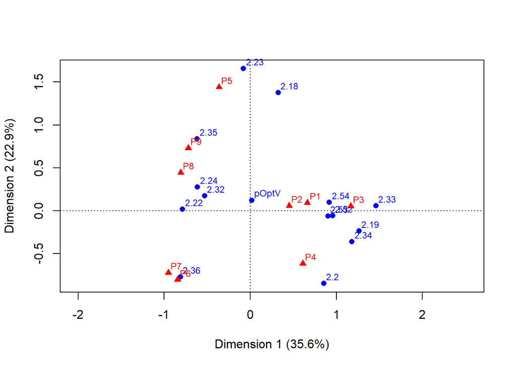

```r
plot(ca(UVMposF.tab))
```

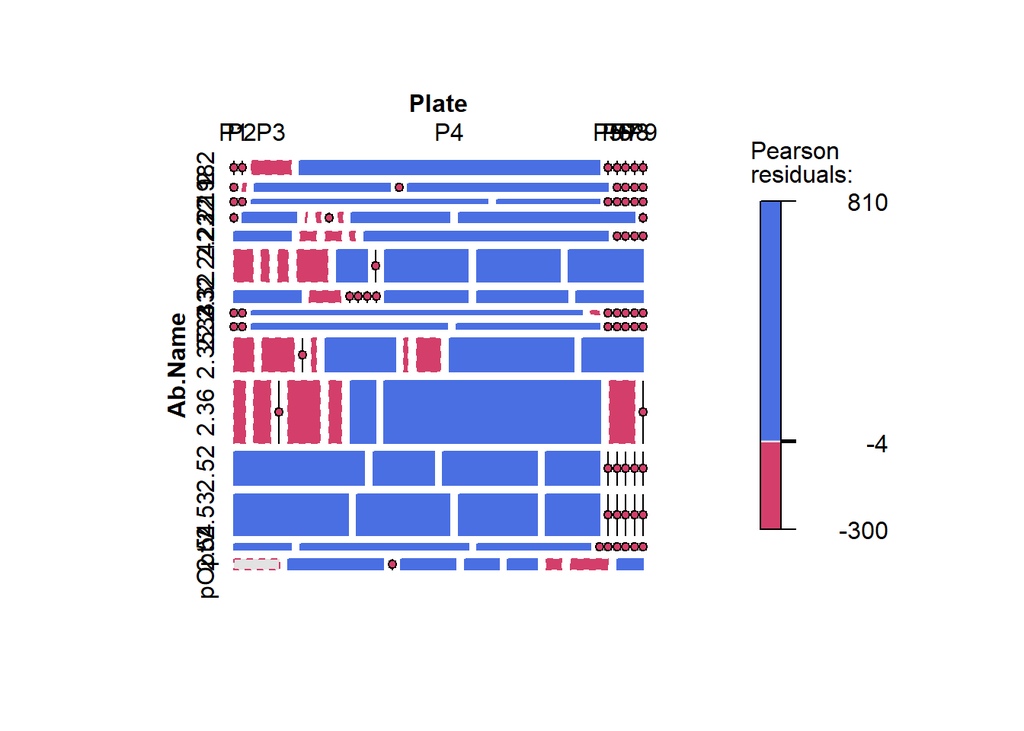

```r
# full.mlr.UVMposF <- lm(Median~Ab.Name+Plate+plateName, data = UVM.posF)
# anova(red.mlr.UVMposF,full.mlr.UVMposF)
# summary(full.mlr.UVMposF)
UVM.posF$MedianI <- as.integer(UVM.posF$Median)

indep.UVMpos <- glm(MedianI~Ab.Name+Plate, family = poisson, data = UVM.posF) #linear model for independent variables
AbScore <- as.numeric(UVM.posF$Ab.Name) #use vars as numeric "dummy"
PltScore <- as.numeric(UVM.posF$Plate)

Abeffect <- glm(MedianI~Ab.Name+Plate+PltScore:Ab.Name, family = poisson, data = UVM.posF) #linear model for column effect i.e. Plate
Plteffect <- glm(MedianI~Ab.Name+Plate+Plate:AbScore, family = poisson, data = UVM.posF) #linear model for row effect i.e. Ab.Name
linlineff <- glm(MedianI~Ab.Name+Plate+PltScore:AbScore, family = poisson, data = UVM.posF) #linear x linear association

# LRstats(glmlist(indep.UVMpos,Abeffect,Plteffect,linlineff)) #summarize and compare models with AIC and BIC (lower is better)

# anova(indep.UVMpos,linlineff,Abeffect, test = "Chisq")
# anova(indep.UVMpos,linlineff,Plteffect, test = "Chisq")

mosaic(~Ab.Name+Plate, data=UVMposF.tab, gp = shading_Friendly2)
```

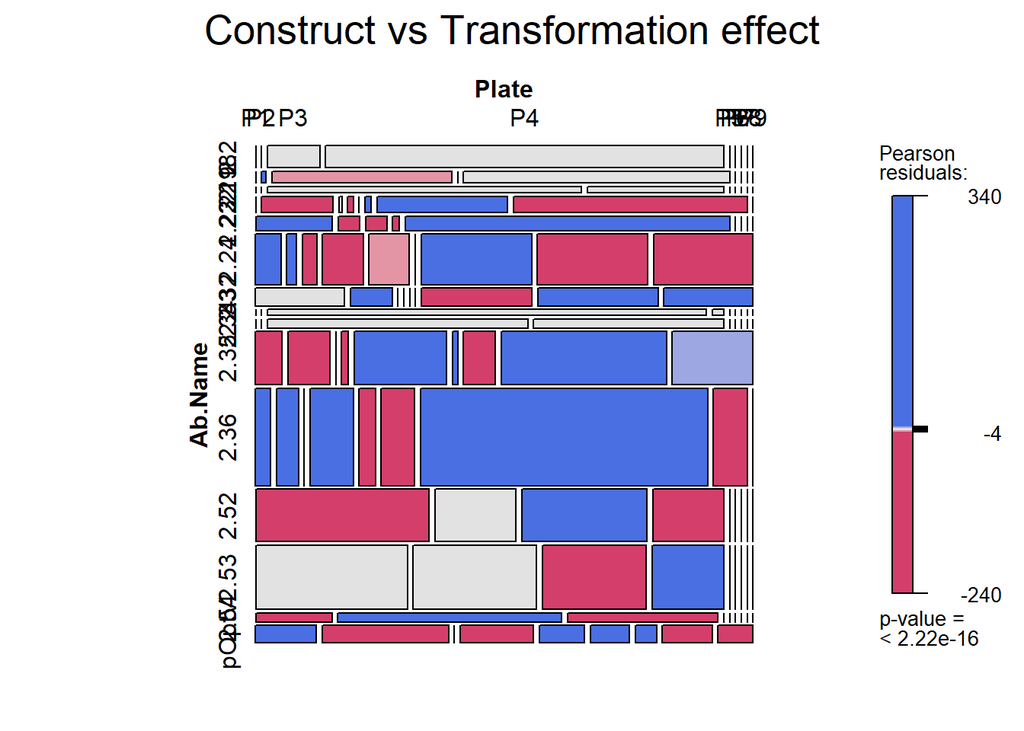

```r
mosaic(Abeffect, ~Ab.Name+Plate, residuals_type = "rstandard", zero_size = 0, spacing = spacing_increase, spacing_args = list(start = 0.2, rate = 0.6), legend_width = 0.5, legend = legend_resbased(fontsize = 10,text = "Pearson\nresiduals:"), main = "Construct vs Transformation effect")
```

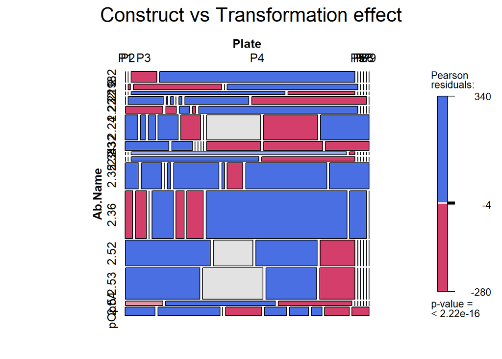

```r
mosaic(linlineff, ~Ab.Name+Plate, residuals_type = "rstandard", zero_size = 0, spacing = spacing_increase, spacing_args = list(start = 0.2, rate = 0.6), legend_width = 0.5, legend = legend_resbased(fontsize = 10,text = "Pearson\nresiduals:"), main = "Construct vs Transformation effect")
```

```r
UVM.posLvl <- UVM.posF
UVM.posLvl$Exp.Lvl <- ifelse(UVM.posLvl$Median > 5*UVM.median.V, "High",
                             ifelse(UVM.posLvl$Median > 2*UVM.median.V & UVM.posLvl$Median < 5*UVM.median.V, "Medium", "Low"))
# levels(UVM.posLvl$Ab.Name)
UVM.posLvl$Ab.Name <- factor(UVM.posLvl$Ab.Name, c("2.2", "2.18", "2.19", "2.22", "2.23", "2.24","2.32","2.33","2.34","2.35","2.36","2.52","2.53","2.54","pOptV"))

# HML.lm1 <- loglm(~(Exp.Lvl+Ab.Name)+Plate, data = UVM.posLvl)

HML.4tab1 <- xtabs(Median~Ab.Name+Plate+Exp.Lvl, data = UVM.posLvl)
# structable(Ab.Name+Plate~Exp.Lvl, data = HML.4tab1)



write.csv(UVM.posLvl, "UVM_posLvl.csv")
UVM.posLvlcsv <- read.csv("UVM_posLvl.csv")
# str(UVM.posLvlcsv)
UVM.posLvlcsv$Exp.Lvl <- ordered(UVM.posLvlcsv$Exp.Lvl, c("Low","Medium","High"))

xtbl.UVM.Plt <- xtabs(~Exp.Lvl+Plate, data = UVM.posLvlcsv)
ftable(xtbl.UVM.Plt)
```

```
##         Plate  P1  P2  P3  P4  P5  P6  P7  P8  P9
## Exp.Lvl
## Low           187 185 168 137  86  75  81  49  43
## Medium         68  60  65  37  40   4  45 105  58
## High           16   7   7  22  13   0  31   5   0
```

```r
summary(xtbl.UVM.Plt)
```

```
## Call: xtabs(formula = ~Exp.Lvl + Plate, data = UVM.posLvlcsv)
## Number of cases in table: 1594
## Number of factors: 2
## Test for independence of all factors:
##  Chisq = 258.97, df = 16, p-value = 7.456e-46
```

```r
xtbl.UVM.Ab <- xtabs(~Exp.Lvl+Ab.Name, data = UVM.posLvlcsv)
# ftable(xtbl.UVM.Ab)
# summary(xtbl.UVM.Ab)

xtbl.UVMposF <- xtabs(~Exp.Lvl+Ab.Name+Plate, data=UVM.posLvl)
# ftable(xtbl.UVMposF)
# summary(xtbl.UVMposF)

tbl.UVM.posLvlcsv <- with(UVM.posLvlcsv, table(Exp.Lvl, plateName))
# tbl.UVM.posLvlcsv
```

####Principal Component Analysis

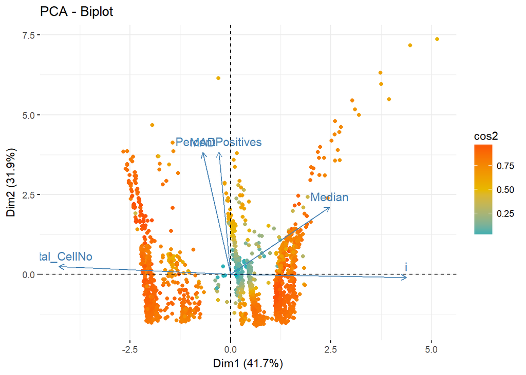

```r
write.csv(UVM.posLvl, "UVMposLvl.csv")
# View(UVM.posLvl)
UVM.Lvl.short <- UVM.posLvl[c("Ab.Name","Total_CellNo","Median","MAD","i","PercentPositives")]
UVM.Lvl.short$Total_CellNo <- as.numeric(UVM.Lvl.short$Total_CellNo)
UVM.Lvl.short$i <- as.numeric(UVM.Lvl.short$i)
# str(UVM.Lvl.short)
UVMlvlshort1 <- UVM.Lvl.short[-1]
rownames(UVMlvlshort1) <- make.names(UVM.Lvl.short$Ab.Name, unique = TRUE)
# head(UVMlvlshort1)
UVMlvl.pca <- prcomp(UVMlvlshort1, scale. = TRUE)
# fviz_eig(UVMlvl.pca)
# summary(UVMlvl.pca)
factoextra::fviz_pca_biplot(UVMlvl.pca, geom = c("point"), col.ind = "cos2" ,gradient.cols = c("#00AFBB", "#E7B800", "#FC4E07"))
```

```r
# str(UVM.Lvl.short)

Constructs <- factor(UVM.Lvl.short$Ab.Name)
UVMlvl.pca2 <- prcomp(scale(UVM.Lvl.short[,-1]))
UVMlvl.pca2
```

```
## Standard deviations (1, .., p=5):
## [1] 1.4441227 1.2638410 0.8322322 0.7134325 0.3400280
##
## Rotation (n x k) = (5 x 5):
##                          PC1         PC2        PC3         PC4
## Total_CellNo     -0.64358687  0.04210759 -0.3216085  0.12499376
## Median            0.37152181  0.36311360 -0.8494077  0.04582499
## MAD              -0.10360597  0.65729526  0.1891365 -0.71740996
## i                 0.65959967 -0.01595641  0.2148325  0.02933484
## PercentPositives -0.04428952  0.65885036  0.3052030  0.68318303
##                          PC5
## Total_CellNo     -0.68188517
## Median            0.08078765
## MAD              -0.08233515
## i                -0.71948603
## PercentPositives  0.06377099
```

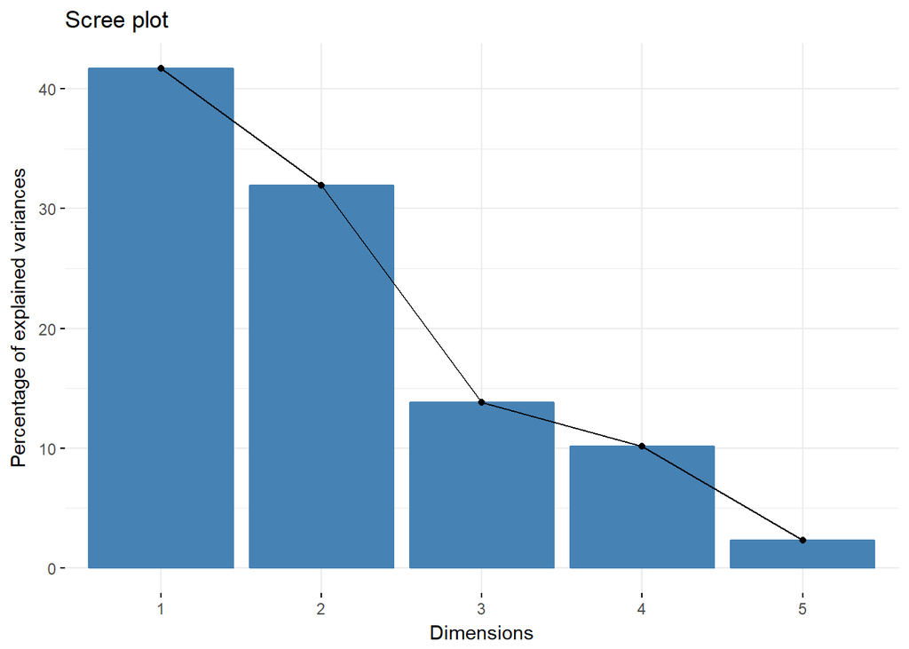

```r
factoextra::fviz_eig(UVMlvl.pca2)
```

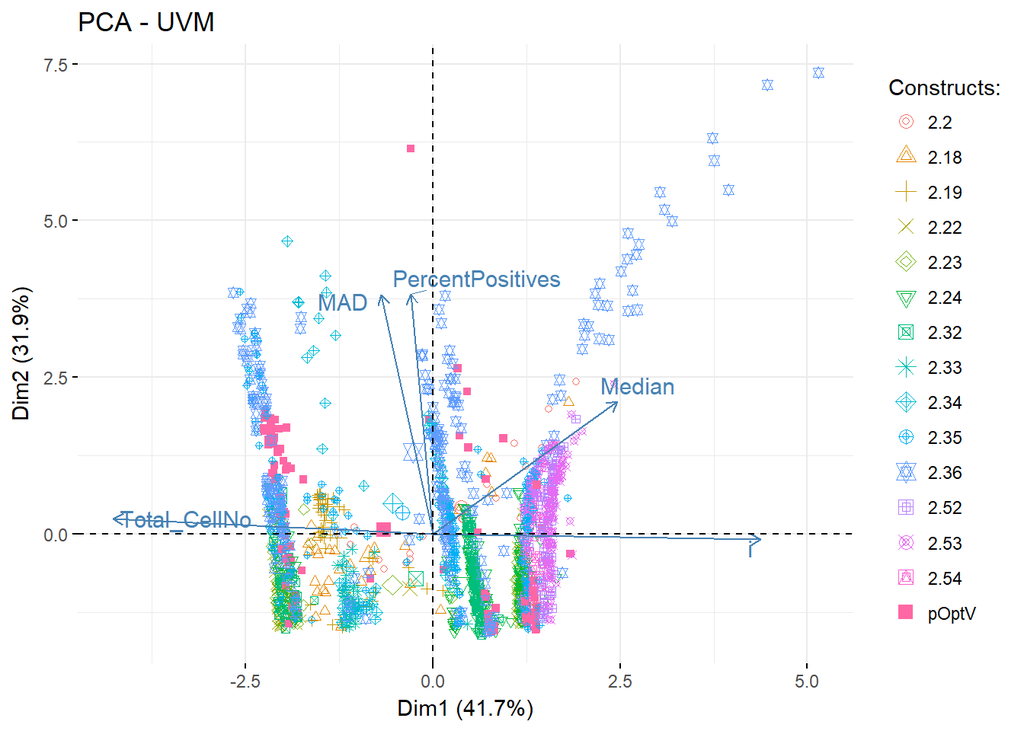

```r
UVM.pcaSum <- summary(UVMlvl.pca2)
# write.csv(UVM.pcaSum, "UVM_PCA-summary.csv")
factoextra::fviz_pca_biplot(UVMlvl.pca2, geom = c("point"), col.ind = Constructs, title = "PCA - UVM" ,legend.title = "Constructs:" ,gradient.cols = c("#00AFBB", "#E7B800", "#FC4E07"), repel = TRUE)
```

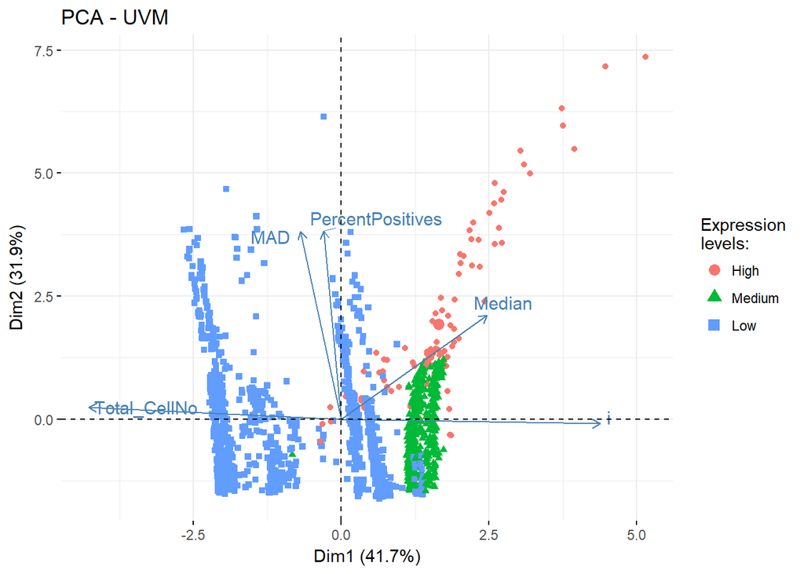

```r
Explevels <- factor(UVM.posLvl$Exp.Lvl, c("High","Medium","Low"))
factoextra::fviz_pca_biplot(UVMlvl.pca2, geom = c("point"), col.ind = Explevels, title = "PCA - UVM" ,legend.title = "Expression\nlevels:" ,gradient.cols = c("#00AFBB", "#E7B800", "#FC4E07"), repel = TRUE)
```

####Defining threshold for High/Medium/Low expressors and ploting the results - UVM

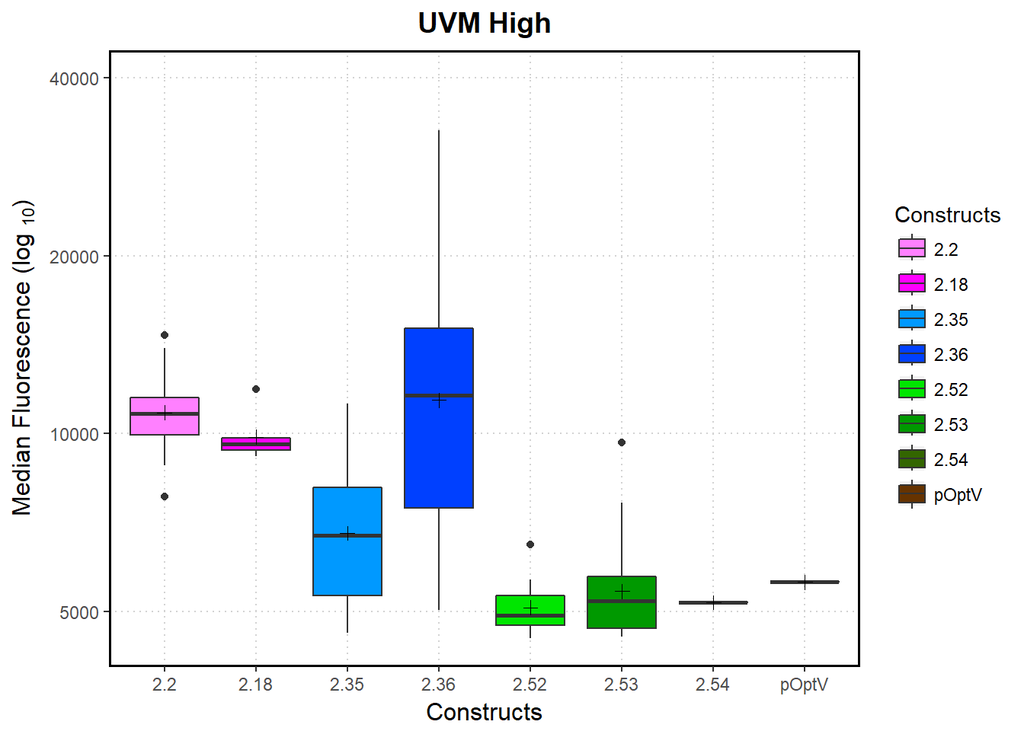

```r
npos <- nrow(UVM.posF)
# npos
UVM.pos.High <- subset(UVM.posF, Median > 5*UVM.median.V)
# nHigh <- nrow(UVM.pos.High)
# nHigh/npos
UVM.pos.Medium <- subset(UVM.posF, Median > 2*UVM.median.V & Median < 5*UVM.median.V)
# nMed <- nrow(UVM.pos.Medium)
# nMed/npos
UVM.pos.Low <- subset(UVM.posF, Median < 2*UVM.median.V)
# nLow <- nrow(UVM.pos.Low)
# nLow/npos

# View(UVM.pos.High)
box.UVM.pos.High <- ggplot(UVM.pos.High, aes(x=Ab.Name, y=Median))
box.UVM.pos.High + geom_boxplot(aes(fill =Ab.Name))+
   labs(title = "UVM High", x = "Constructs", y = expression("Median Fluorescence (log  "[10]*")"), fill = "Constructs")+
  theme(
        axis.text.x = element_text(angle = 0, vjust = 0.5),
        plot.title = element_text(color="black", size=14, face="bold", hjust = 0.5),
        axis.title.x = element_text(color="black", size=12),
        axis.title.y = element_text(color="black", size=12),
        line = element_line(colour = "black", size = 0.5, linetype = 1, lineend = "butt"),
        rect = element_rect(fill = "white", colour = "black", size = 2.5, linetype = 1),
        panel.border = element_rect(size = 1, fill = NA),
        panel.background = element_rect(fill = "white"),
        panel.grid.major = element_line(color = "lightgrey",size = 0.5, linetype = 3)
    )+
  scale_y_log10(breaks=c(5000,10000,20000,40000), limits = c(4500,40000))+
  scale_fill_manual(values = mycolors, name = "Constructs")+
  guides(color=guide_legend(ncol=2))+
  stat_summary(fun.y = mean, geom = "point",shape=3,size=2, position = position_dodge(width = 0.75))+
  stat_compare_means(label="p.signif",ref.group = "pOptV", hide.ns = TRUE) #Welshe's t-test
```

```r
UVM.express <- UVM.posF %>%
  group_by(Ab.Name) %>%
  count()
UVM.express=as.data.frame(UVM.express)
colnames(UVM.express) <- c("Constructs","Total.Positives")
# View(UVM.express)

UVM.exH <- UVM.pos.High %>%
  group_by(Ab.Name) %>%
  count()
UVM.exH=as.data.frame(UVM.exH)
colnames(UVM.exH) <- c("Constructs","High.Exp")
# View(UVM.exH)

UVM.exM <- UVM.pos.Medium %>%
  group_by(Ab.Name) %>%
  count()
UVM.exM=as.data.frame(UVM.exM)
colnames(UVM.exM) <- c("Constructs","Medium.Exp")
# View(UVM.exM)

UVM.exL <- UVM.pos.Low %>%
  group_by(Ab.Name) %>%
  count()
UVM.exL=as.data.frame(UVM.exL)
colnames(UVM.exL) <- c("Constructs","Low.Exp")
# View(UVM.exL)

UVM.express.ALL <- merge(UVM.express, UVM.exH, by = c("Constructs"),all=TRUE)
UVM.express.ALL$High.Per <- with(UVM.express.ALL, High.Exp / Total.Positives * 100)
# UVM.express.ALL

UVM.express.ALL <- merge(UVM.express.ALL, UVM.exM, by = c("Constructs"),all=TRUE)
UVM.express.ALL$Medium.Per <- with(UVM.express.ALL, Medium.Exp / Total.Positives * 100)

UVM.express.ALL <- merge(UVM.express.ALL, UVM.exL, by = c("Constructs"),all=TRUE)
UVM.express.ALL$Low.Per <- with(UVM.express.ALL, Low.Exp / Total.Positives * 100)
UVM.expALL.long <- UVM.express.ALL %>% gather(Expression.Per, Percentage, c(Low.Per,Medium.Per,High.Per))
UVM.expALL.long$Expression.Per <- factor(UVM.expALL.long$Expression.Per, c("High.Per","Medium.Per","Low.Per"))
UVM.express.num <- merge(UVM.exH, UVM.exM, by = c("Constructs"),all=TRUE)
UVM.express.num <- merge(UVM.express.num, UVM.exL, by = c("Constructs"),all=TRUE)
UVM.expnum.long <- UVM.express.num %>% gather(Expression, Population, c(High.Exp,Medium.Exp,Low.Exp))
UVM.expnum.long$Expression <- factor(UVM.expnum.long$Expression, c("High.Exp","Medium.Exp","Low.Exp"))
# UVM.expnum.long

UVM.constr <- unique(UVM.FD$Ab.Name)
# UVM.constr
colorCount <- length(UVM.constr)
moreColors <- colorRampPalette(brewer.pal(9,"Set1"))



UVM.express.num <- merge(UVM.exH, UVM.exM, by = c("Constructs"),all=TRUE)
UVM.express.num <- merge(UVM.express.num, UVM.exL, by = c("Constructs"),all=TRUE)
UVM.expnum.long <- UVM.express.num %>% gather(Expression, Population, c(High.Exp,Medium.Exp,Low.Exp))
UVM.expnum.long[is.na(UVM.expnum.long)] <- 0
UVM.expnum.long$Expression <- factor(UVM.expnum.long$Expression, c("Low.Exp","Medium.Exp","High.Exp"))

UVM.expnum.PL <- UVM.expnum.long %>%
  group_by(Constructs, Expression) %>%
  dplyr::summarise(n=Population) %>%
  mutate(percent = ((n / sum(n))*100), cumsum=cumsum(percent), label=ifelse(Expression=="High.Exp", paste0("N=",sum(n)),""))
UVM.expnum.PL$Expression <- factor(UVM.expnum.PL$Expression, c("High.Exp","Medium.Exp","Low.Exp"))
UVM.expnum.PL$percent[UVM.expnum.PL$percent == 0] <- NA
UVM.expnum.PL <- as.data.frame(UVM.expnum.PL)
UVM.expnum.PL$Per <- UVM.expnum.PL$percent*100
UVM.expnum.PL
```

```
##    Constructs Expression   n     percent    cumsum label         Per
## 1         2.2    Low.Exp   8  38.0952381  38.09524        3809.52381
## 2         2.2 Medium.Exp   0          NA  38.09524                NA
## 3         2.2   High.Exp  13  61.9047619 100.00000  N=21  6190.47619
## 4        2.18    Low.Exp  27  81.8181818  81.81818        8181.81818
## 5        2.18 Medium.Exp   0          NA  81.81818                NA
## 6        2.18   High.Exp   6  18.1818182 100.00000  N=33  1818.18182
## 7        2.19    Low.Exp  43 100.0000000 100.00000       10000.00000
## 8        2.19 Medium.Exp   0          NA 100.00000                NA
## 9        2.19   High.Exp   0          NA 100.00000  N=43          NA
## 10       2.22    Low.Exp  35  47.9452055  47.94521        4794.52055
## 11       2.22 Medium.Exp  38  52.0547945 100.00000        5205.47945
## 12       2.22   High.Exp   0          NA 100.00000  N=73          NA
## 13       2.23    Low.Exp  43  55.8441558  55.84416        5584.41558
## 14       2.23 Medium.Exp  34  44.1558442 100.00000        4415.58442
```

[output cut: 31 more lines]

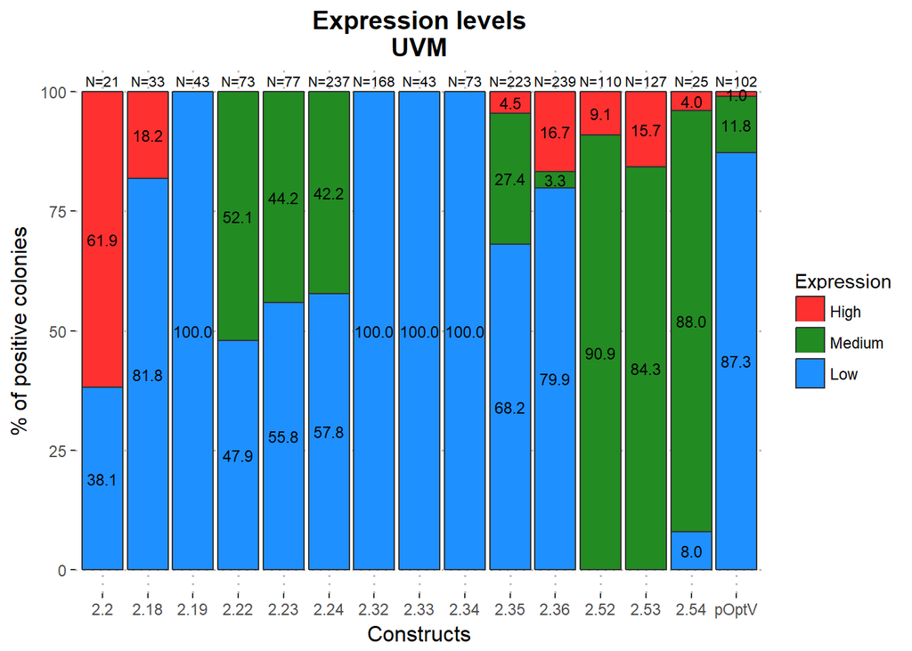

```r
bar.UVM.PL <- ggplot(UVM.expnum.PL, aes(x=Constructs, y=percent, fill = Expression))
bar.UVM.PL + geom_bar(stat = "identity", color = "gray20")+
  labs(title = "Expression levels\nUVM", y = "% of positive colonies", x = "Constructs")+
  theme(
        axis.text.x = element_text(angle = 0, vjust = 0.5),
        plot.title = element_text(color="black", size=14, face="bold", hjust = 0.5),
        axis.title.x = element_text(color="black", size=12),
        axis.title.y = element_text(color="black", size=12),
        line = element_line(colour = "black", size = 0.5, linetype = 1, lineend = "butt"),
        rect = element_rect(fill = "white", colour = "black", size = 2.5, linetype = 1),
        panel.background = element_rect(fill = "white"),
        panel.grid.major = element_line(color = "grey",size = 0.6, linetype = 3)
    )+
  scale_fill_manual(labels = c("High","Medium","Low"),values = c("firebrick1","forestgreen","dodgerblue1"), name = "Expression")+
  geom_text(aes(label=label, y=cumsum), vjust = -0.5, size=2.75)+
  geom_text(aes(label = sprintf("%0.1f", round(percent, digits = 1))),size = 3, position = position_stack(vjust = 0.5))
```

####High/Medium/Low expression populations and plotting - Baf

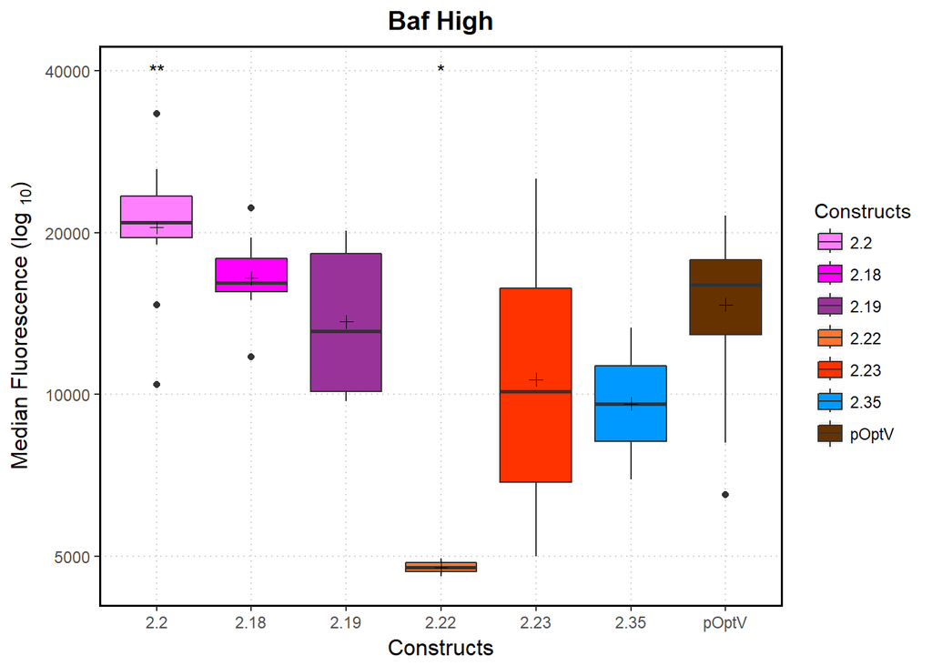

```r
Baf.pos.High <- subset(Baf.posF, Median > 5*UVM.median.V)
Baf.pos.Medium <- subset(Baf.posF, Median > 2*UVM.median.V & Median < 5*UVM.median.V)
Baf.pos.Low <- subset(Baf.posF, Median < 2*UVM.median.V)

Baf.express <- Baf.posF %>%
  group_by(Ab.Name) %>%
  count()
Baf.express=as.data.frame(Baf.express)
colnames(Baf.express) <- c("Constructs","Total.Positives")

Baf.exH <- Baf.pos.High %>%
  group_by(Ab.Name) %>%
  count()
Baf.exH=as.data.frame(Baf.exH)
colnames(Baf.exH) <- c("Constructs","High.Exp")

Baf.exM <- Baf.pos.Medium %>%
  group_by(Ab.Name) %>%
  count()
Baf.exM=as.data.frame(Baf.exM)
colnames(Baf.exM) <- c("Constructs","Medium.Exp")

Baf.exL <- Baf.pos.Low %>%
  group_by(Ab.Name) %>%
  count()
Baf.exL=as.data.frame(Baf.exL)
colnames(Baf.exL) <- c("Constructs","Low.Exp")

Baf.express.ALL <- merge(Baf.express, Baf.exH, by = c("Constructs"),all=TRUE)
Baf.express.ALL$High.Per <- with(Baf.express.ALL, High.Exp / Total.Positives * 100)
# Baf.express.ALL

Baf.express.ALL <- merge(Baf.express.ALL, Baf.exM, by = c("Constructs"),all=TRUE)
Baf.express.ALL$Medium.Per <- with(Baf.express.ALL, Medium.Exp / Total.Positives * 100)

Baf.express.ALL <- merge(Baf.express.ALL, Baf.exL, by = c("Constructs"),all=TRUE)
Baf.express.ALL$Low.Per <- with(Baf.express.ALL, Low.Exp / Total.Positives * 100)
Baf.expALL.long <- Baf.express.ALL %>% gather(Expression.Per, Percentage, c(Low.Per,Medium.Per,High.Per))
Baf.expALL.long$Expression.Per <- factor(Baf.expALL.long$Expression.Per, c("High.Per","Medium.Per","Low.Per"))




# View(Baf.pos.High)
box.Baf.pos.High <- ggplot(Baf.pos.High, aes(x=Ab.Name, y=Median))
box.Baf.pos.High + geom_boxplot(aes(fill =Ab.Name))+
   labs(title = "Baf High", x = "Constructs", y = expression("Median Fluorescence (log  "[10]*")"), fill = "Constructs")+
  theme(
        axis.text.x = element_text(angle = 0, vjust = 0.5),
        plot.title = element_text(color="black", size=14, face="bold", hjust = 0.5),
        axis.title.x = element_text(color="black", size=12),
        axis.title.y = element_text(color="black", size=12),
        line = element_line(colour = "black", size = 0.5, linetype = 1, lineend = "butt"),
        rect = element_rect(fill = "white", colour = "black", size = 2.5, linetype = 1),
        panel.border = element_rect(size = 1, fill = NA),
        panel.background = element_rect(fill = "white"),
        panel.grid.major = element_line(color = "lightgrey",size = 0.5, linetype = 3)
    )+
  scale_y_log10(breaks=c(5000,10000,20000,40000), limits = c(4500,40000))+
  scale_fill_manual(values = mycolors, name = "Constructs")+
  guides(color=guide_legend(ncol=2))+
  stat_summary(fun.y = mean, geom = "point",shape=3,size=2, position = position_dodge(width = 0.75))+
  stat_compare_means(label="p.signif",ref.group = "pOptV", hide.ns = TRUE) #Welshe's t-test
```

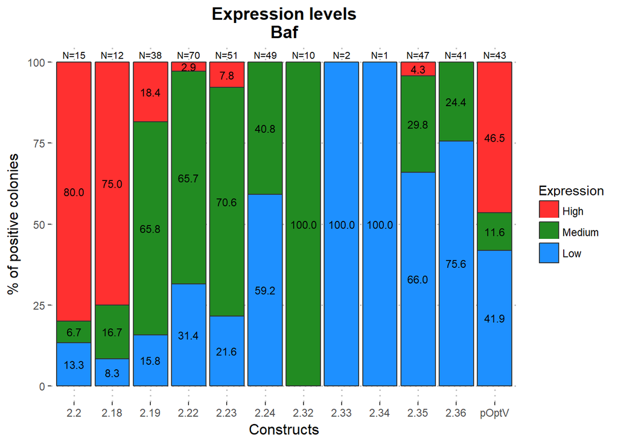

```r
Baf.express.num <- merge(Baf.exH, Baf.exM, by = c("Constructs"),all=TRUE)
Baf.express.num <- merge(Baf.express.num, Baf.exL, by = c("Constructs"),all=TRUE)
Baf.expnum.long <- Baf.express.num %>% gather(Expression, Population, c(High.Exp,Medium.Exp,Low.Exp))
Baf.expnum.long$Expression <- factor(Baf.expnum.long$Expression, c("Low.Exp","Medium.Exp","High.Exp"))


# Baf.expALL.long

Baf.expressLabel <- Baf.express
Baf.expressLabel$Percentage <- with(Baf.expressLabel, c(99))
Baf.expressLabel$Expression.Per <- with(Baf.expressLabel, c(100))

Baf.express.num <- merge(Baf.exH, Baf.exM, by = c("Constructs"),all=TRUE)
Baf.express.num <- merge(Baf.express.num, Baf.exL, by = c("Constructs"),all=TRUE)
Baf.expnum.long <- Baf.express.num %>% gather(Expression, Population, c(High.Exp,Medium.Exp,Low.Exp))
Baf.expnum.long[is.na(Baf.expnum.long)] <- 0
Baf.expnum.long$Expression <- factor(Baf.expnum.long$Expression, c("Low.Exp","Medium.Exp","High.Exp"))
Baf.expnum.PL <- Baf.expnum.long %>%
  group_by(Constructs, Expression) %>%
  dplyr::summarise(n=Population) %>%
  mutate(percent = (n / sum(n)*100), cumsum=cumsum(percent), label=ifelse(Expression=="High.Exp", paste0("N=",sum(n)),""))
Baf.expnum.PL$Expression <- factor(Baf.expnum.PL$Expression, c("High.Exp","Medium.Exp","Low.Exp"))
Baf.expnum.PL$percent[Baf.expnum.PL$percent == 0] <- NA
Baf.expnum.PL <- as.data.frame(Baf.expnum.PL)
# Baf.expnum.PL
bar.Baf.PL <- ggplot(Baf.expnum.PL, aes(x=Constructs, y=percent, fill = Expression))
bar.Baf.PL + geom_bar(stat = "identity", color = "gray20")+
  labs(title = "Expression levels\nBaf", y = "% of positive colonies", x = "Constructs")+
  theme(
        axis.text.x = element_text(angle = 0, vjust = 0.5),
        plot.title = element_text(color="black", size=14, face="bold", hjust = 0.5),
        axis.title.x = element_text(color="black", size=12),
        axis.title.y = element_text(color="black", size=12),
        line = element_line(colour = "black", size = 0.5, linetype = 1, lineend = "butt"),
        rect = element_rect(fill = "white", colour = "black", size = 2.5, linetype = 1),
        panel.background = element_rect(fill = "white"),
        panel.grid.major = element_line(color = "grey",size = 0.6, linetype = 3)
    )+
  # scale_y_continuous(labels = percent)+
  scale_fill_manual(labels = c("High","Medium","Low"),values = c("firebrick1","forestgreen","dodgerblue1"), name = "Expression")+
  geom_text(aes(label=label, y=cumsum), vjust = -0.5, size=2.75)+
  geom_text(aes(label = sprintf("%0.1f", round(percent, digits = 1))),size = 3, position = position_stack(vjust = 0.5))
```

####High/Medium/Low expression populations and plotting - WT

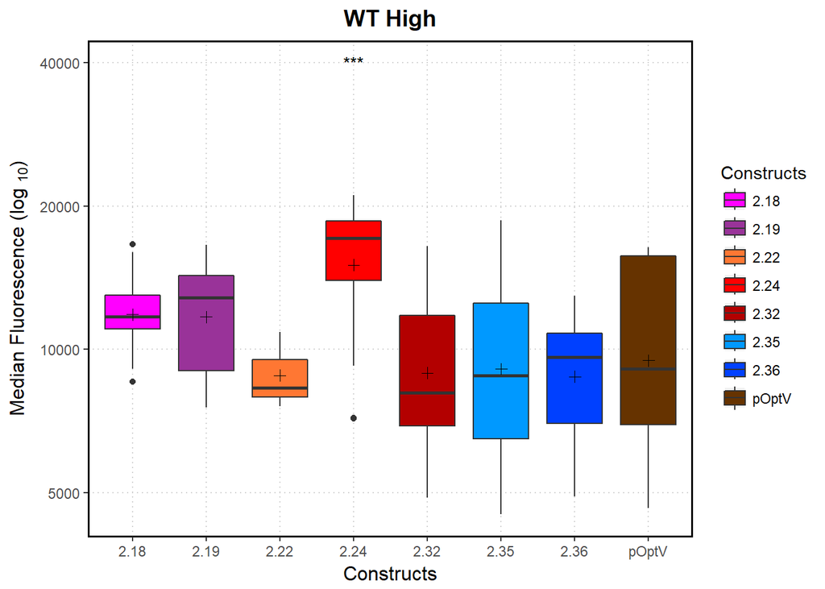

```r
WT.pos.High <- subset(WT.posF, Median > 5*UVM.median.V)
WT.pos.Medium <- subset(WT.posF, Median > 2*UVM.median.V & Median < 5*UVM.median.V)
WT.pos.Low <- subset(WT.posF, Median < 2*UVM.median.V)

WT.express <- WT.posF %>%
  group_by(Ab.Name) %>%
  count()
WT.express=as.data.frame(WT.express)
colnames(WT.express) <- c("Constructs","Total.Positives")

WT.exH <- WT.pos.High %>%
  group_by(Ab.Name) %>%
  count()
WT.exH=as.data.frame(WT.exH)
colnames(WT.exH) <- c("Constructs","High.Exp")

WT.exM <- WT.pos.Medium %>%
  group_by(Ab.Name) %>%
  count()
WT.exM=as.data.frame(WT.exM)
colnames(WT.exM) <- c("Constructs","Medium.Exp")

WT.exL <- WT.pos.Low %>%
  group_by(Ab.Name) %>%
  count()
WT.exL=as.data.frame(WT.exL)
colnames(WT.exL) <- c("Constructs","Low.Exp")

WT.express.ALL <- merge(WT.express, WT.exH, by = c("Constructs"),all=TRUE)
WT.express.ALL$High.Per <- with(WT.express.ALL, High.Exp / Total.Positives * 100)
# WT.express.ALL

WT.express.ALL <- merge(WT.express.ALL, WT.exM, by = c("Constructs"),all=TRUE)
WT.express.ALL$Medium.Per <- with(WT.express.ALL, Medium.Exp / Total.Positives * 100)

WT.express.ALL <- merge(WT.express.ALL, WT.exL, by = c("Constructs"),all=TRUE)
WT.express.ALL$Low.Per <- with(WT.express.ALL, Low.Exp / Total.Positives * 100)
WT.expALL.long <- WT.express.ALL %>% gather(Expression.Per, Percentage, c(Low.Per,Medium.Per,High.Per))
WT.expALL.long$Expression.Per <- factor(WT.expALL.long$Expression.Per, c("High.Per","Medium.Per","Low.Per"))




# View(WT.pos.High)
box.WT.pos.High <- ggplot(WT.pos.High, aes(x=Ab.Name, y=Median))
box.WT.pos.High + geom_boxplot(aes(fill =Ab.Name))+
   labs(title = "WT High", x = "Constructs", y = expression("Median Fluorescence (log  "[10]*")"), fill = "Constructs")+
  theme(
        axis.text.x = element_text(angle = 0, vjust = 0.5),
        plot.title = element_text(color="black", size=14, face="bold", hjust = 0.5),
        axis.title.x = element_text(color="black", size=12),
        axis.title.y = element_text(color="black", size=12),
        line = element_line(colour = "black", size = 0.5, linetype = 1, lineend = "butt"),
        rect = element_rect(fill = "white", colour = "black", size = 2.5, linetype = 1),
        panel.border = element_rect(size = 1, fill = NA),
        panel.background = element_rect(fill = "white"),
        panel.grid.major = element_line(color = "lightgrey",size = 0.5, linetype = 3)
    )+
  scale_y_log10(breaks=c(5000,10000,20000,40000), limits = c(4500,40000))+
  scale_fill_manual(values = mycolors, name = "Constructs")+
  guides(color=guide_legend(ncol=2))+
  stat_summary(fun.y = mean, geom = "point",shape=3,size=2, position = position_dodge(width = 0.75))+
  stat_compare_means(label="p.signif",ref.group = "pOptV", hide.ns = TRUE) #Welshe's t-test
```